# Donor Prediction - Group5

```python
import sys
import numpy as np
from sklearn.model_selection import train_test_split, GridSearchCV
from pandas                 import DataFrame
from pandas                 import read_csv
from numpy                  import array
from numpy                  import random
from sklearn.linear_model   import LogisticRegression
from sklearn.tree           import DecisionTreeClassifier
from sklearn.ensemble       import RandomForestClassifier
from sklearn.ensemble       import GradientBoostingClassifier
from sklearn.svm            import SVC
from sklearn.neural_network import MLPClassifier
from sklearn.neighbors      import KNeighborsClassifier
from sklearn.metrics        import accuracy_score
from sklearn.metrics        import auc
from sklearn.metrics        import roc_auc_score
from matplotlib             import pyplot
from sklearn.metrics import ConfusionMatrixDisplay
from sklearn.metrics import confusion_matrix, accuracy_score
import kds
from sklearn.metrics import confusion_matrix, roc_auc_score, classification_report, ConfusionMatrixDisplay
import matplotlib.pyplot as plt
import numpy as np
import pandas as pd
from sklearn.model_selection import train_test_split, RandomizedSearchCV
from sklearn.preprocessing import StandardScaler
from sklearn.pipeline import Pipeline
from sklearn.feature_selection import SequentialFeatureSelector
from sklearn.tree import DecisionTreeClassifier
from sklearn.linear_model import LogisticRegression
from sklearn.ensemble import RandomForestClassifier, GradientBoostingClassifier
from sklearn.svm import SVC
from sklearn.neural_network import MLPClassifier
from sklearn.neighbors import KNeighborsClassifier
from sklearn.metrics import roc_auc_score, classification_report
from sklearn.metrics import confusion_matrix, roc_auc_score, classification_report, ConfusionMatrixDisplay
from sklearn.ensemble import RandomForestClassifier, GradientBoostingClassifier
from sklearn.neural_network import MLPClassifier
```

## 1. Read the data in csv

```python
import sys

import pandas as pd
import numpy as np
import matplotlib.pyplot as plt
from scipy.stats.mstats import winsorize
import seaborn as sns

import warnings
warnings.filterwarnings('ignore')
```

```python
campaigns = pd.read_csv('./data/campaigns.csv', sep=';')
donors = pd.read_csv('./data/donors.csv', sep=',')
gifts = pd.read_csv('./data/gifts.csv', sep=',')
train = pd.read_csv('./data/selection campaign 6169.csv')
validation = pd.read_csv('./data/selection campaign 7244.csv')
```

```python
campaigns = campaigns.rename(columns = {'date':'date_of_campaign'})
```

```python
campaigns.head()
```

|  | campaignID | date_of_campaign | lettersSent | CostUnit |
| --- | --- | --- | --- | --- |
| 0 | 153 | 13/12/2004 | 6 873 | 0,17 € |
| 1 | 154 | 01/01/2005 | 7 656 | 0,30 € |
| 2 | 180 | 18/01/2005 | 9 933 | 0,20 € |
| 3 | 433 | 29/01/2005 | 7 448 | 0,59 € |
| 4 | 476 | 12/02/2005 | 6 605 | 0,51 € |

```python
gifts = gifts.rename(columns = {'date':'date_of_donation'})
```

```python
gifts.head()
```

|  | donorID | campaignID | amount | date_of_donation |
| --- | --- | --- | --- | --- |
| 0 | D100001 | NaN | 12,39 | 23/03/2004 |
| 1 | D100001 | 1577.0 | 12,39 | 11/10/2007 |
| 2 | D100001 | 1634.0 | 6,69 | 28/12/2007 |
| 3 | D100001 | 1778.0 | 24,79 | 14/06/2008 |
| 4 | D100001 | 1808.0 | 7,44 | 09/07/2008 |

```python
donors.head()
```

|  | donorID | zipcode | province | region | gender | language | dateOfBirth |
| --- | --- | --- | --- | --- | --- | --- | --- |
| 0 | D100001 | 1861.0 | Flemish Brabant | Flanders | F | NL | 12/24/1967 |
| 1 | D100002 | 2260.0 | Antwerp | Flanders | M | NL | 01/14/1952 |
| 2 | D100003 | 1780.0 | Flemish Brabant | Flanders | M | NL | 12/23/1986 |
| 3 | D100004 | 1020.0 | Brussels | Brussels | F | FR | 03/29/1952 |
| 4 | D100005 | 1020.0 | Brussels | Brussels | F | FR | 06/25/1986 |

```python
donors['region'].unique()
```

```
array(['Flanders', 'Brussels', 'Wallonia', 'Missing'], dtype=object)
```

```python
base = pd.merge(donors, gifts, how = 'left', on = 'donorID')
base = pd.merge(base, campaigns, how = 'left', on = 'campaignID')
base.head()
```

|  | donorID | zipcode | province | region | gender | language | dateOfBirth | campaignID | amount | date_of_donation | date_of_campaign | lettersSent | CostUnit |
| --- | --- | --- | --- | --- | --- | --- | --- | --- | --- | --- | --- | --- | --- |
| 0 | D100001 | 1861.0 | Flemish Brabant | Flanders | F | NL | 12/24/1967 | NaN | 12,39 | 23/03/2004 | NaN | NaN | NaN |
| 1 | D100001 | 1861.0 | Flemish Brabant | Flanders | F | NL | 12/24/1967 | 1577.0 | 12,39 | 11/10/2007 | 09/10/2007 | 34 636 | 0,31 € |
| 2 | D100001 | 1861.0 | Flemish Brabant | Flanders | F | NL | 12/24/1967 | 1634.0 | 6,69 | 28/12/2007 | 08/12/2007 | 34 080 | 0,21 € |
| 3 | D100001 | 1861.0 | Flemish Brabant | Flanders | F | NL | 12/24/1967 | 1778.0 | 24,79 | 14/06/2008 | 25/05/2008 | 30 558 | 0,41 € |
| 4 | D100001 | 1861.0 | Flemish Brabant | Flanders | F | NL | 12/24/1967 | 1808.0 | 7,44 | 09/07/2008 | 22/06/2008 | 39 664 | 0,61 € |

```python
base_sort = base.sort_values(by='date_of_donation', ascending = False)
```

```python
base['date_of_donation'] = pd.to_datetime(base['date_of_donation'])
```

```python
train = pd.merge(train, base, how = 'left', on = 'donorID')
train = train[train['date_of_donation'] < "2018-08-04"].copy(deep=True)
# we let a month of time gap
```

```python
validation = pd.merge(validation, base, how = 'left', on = 'donorID')
validation = validation[validation['date_of_donation'] < "2019-05-18"].copy(deep=True)
#we let a month of time gap
```

```python
train['amount'] = train['amount'].str.replace(',', '.')
train['amount'] = train['amount'].str.replace(r'\.(?=\d{3})', '', regex=True)
train['amount'] = pd.to_numeric(train['amount'])
```

```python
validation['amount'] = validation['amount'].str.replace(',', '.')
validation['amount'] = validation['amount'].str.replace(r'\.(?=\d{3})', '', regex=True)
validation['amount'] = pd.to_numeric(validation['amount'])
```

## 2. Create independent variables

##### 2.1 Create the independent variable --- LOR, Recency, frequency

2.1.1 Recency and LOR calculation

```python
recent_donation = train.groupby('donorID')['date_of_donation'].max().reset_index()
earliest_donation = train.groupby('donorID')['date_of_donation'].min().reset_index()
```

```python
recent_donation['Recency'] = (pd.to_datetime("2018-08-04") - recent_donation['date_of_donation']).dt.days
earliest_donation['LOR'] = (pd.to_datetime("2018-08-04") - earliest_donation['date_of_donation']).dt.days / 365
```

```python
recent_donation = recent_donation.drop(columns=['date_of_donation'])
earliest_donation = earliest_donation.drop(columns=['date_of_donation'])
```

```python
train = pd.merge(train, recent_donation, how = 'left', on = 'donorID')
train = pd.merge(train, earliest_donation, how = 'left', on = 'donorID')
```

```python
recent_donation1 = validation.groupby('donorID')['date_of_donation'].max().reset_index()
earliest_donation1 = validation.groupby('donorID')['date_of_donation'].min().reset_index()
```

```python
recent_donation1['Recency'] = (pd.to_datetime("2019-05-18") - recent_donation1['date_of_donation']).dt.days
earliest_donation1['LOR'] = (pd.to_datetime("2019-05-18") - earliest_donation1['date_of_donation']).dt.days / 365
```

```python
recent_donation1 = recent_donation1.drop(columns=['date_of_donation'])
earliest_donation1 = earliest_donation1.drop(columns=['date_of_donation'])
```

```python
validation = pd.merge(validation, recent_donation1, how = 'left', on = 'donorID')
validation = pd.merge(validation, earliest_donation1, how = 'left', on = 'donorID')
```

2.1.2 Frequency calculation

```python
frequency = train.groupby('donorID')['amount'].count().reset_index()
# Rename the column for clarity
frequency.rename(columns={'amount': 'nbr_of_donations'}, inplace=True)
```

```python
train = pd.merge(train, frequency, how = 'left', on = 'donorID')
```

```python
frequency1 = validation.groupby('donorID')['amount'].count().reset_index()
# Rename the column for clarity
frequency1.rename(columns={'amount': 'nbr_of_donations'}, inplace=True)
```

```python
validation = pd.merge(validation, frequency1, how = 'left', on = 'donorID')
```

##### 2.2 Create the independent variable --- sum/avg/max/std of amount donated during the relationship and the last donation amount

```python
sum_donation_amount = train.groupby('donorID')['amount'].sum().reset_index()
avg_donation_amount = train.groupby('donorID')['amount'].mean().reset_index()
max_donation_amount = train.groupby('donorID')['amount'].max().reset_index()
std_donation_amount = train.groupby('donorID')['amount'].std().reset_index()
# Rename the column for clarity
sum_donation_amount.rename(columns={'amount': 'sum_donation_amount'}, inplace=True)
avg_donation_amount.rename(columns={'amount': 'avg_donation_amount'}, inplace=True)
max_donation_amount.rename(columns={'amount': 'max_donation_amount'}, inplace=True)
std_donation_amount.rename(columns={'amount': 'std_donation_amount'}, inplace=True)
```

```python
stats = sum_donation_amount.merge(avg_donation_amount, on='donorID') \
                           .merge(max_donation_amount, on='donorID') \
                           .merge(std_donation_amount, on='donorID')
stats.head()
```

|  | donorID | sum_donation_amount | avg_donation_amount | max_donation_amount | std_donation_amount |
| --- | --- | --- | --- | --- | --- |
| 0 | D100001 | 178.49 | 14.874167 | 30.00 | 7.870151 |
| 1 | D100002 | 20.00 | 20.000000 | 20.00 | NaN |
| 2 | D100004 | 716.22 | 27.546923 | 49.58 | 5.142858 |
| 3 | D100008 | 124.37 | 41.456667 | 50.00 | 14.435284 |
| 4 | D100009 | 326.78 | 17.198947 | 25.00 | 5.682107 |

```python
train = pd.merge(train, stats, how = 'left', on = 'donorID')
```

```python
#the last donation amount
last_donation = train.loc[train.groupby('donorID')['date_of_donation'].idxmax()].reset_index(drop=True)
last_donation.rename(columns={'amount': 'last_donation_amount'}, inplace=True)
```

```python
last_donation = last_donation[['donorID', 'last_donation_amount']]
```

```python
train = pd.merge(train, last_donation, how = 'left', on = 'donorID')
train.head()
```

|  | donorID | zipcode | province | region | gender | language | dateOfBirth | campaignID | amount | date_of_donation | ... | lettersSent | CostUnit | Recency | LOR | nbr_of_donations | sum_donation_amount | avg_donation_amount | max_donation_amount | std_donation_amount | last_donation_amount |
| --- | --- | --- | --- | --- | --- | --- | --- | --- | --- | --- | --- | --- | --- | --- | --- | --- | --- | --- | --- | --- | --- |
| 0 | D100001 | 1861.0 | Flemish Brabant | Flanders | F | NL | 12/24/1967 | NaN | 12.39 | 2004-03-23 | ... | NaN | NaN | 2409 | 14.375342 | 12 | 178.49 | 14.874167 | 30.0 | 7.870151 | 10.0 |
| 1 | D100001 | 1861.0 | Flemish Brabant | Flanders | F | NL | 12/24/1967 | 1577.0 | 12.39 | 2007-10-11 | ... | 34 636 | 0,31 € | 2409 | 14.375342 | 12 | 178.49 | 14.874167 | 30.0 | 7.870151 | 10.0 |
| 2 | D100001 | 1861.0 | Flemish Brabant | Flanders | F | NL | 12/24/1967 | 1634.0 | 6.69 | 2007-12-28 | ... | 34 080 | 0,21 € | 2409 | 14.375342 | 12 | 178.49 | 14.874167 | 30.0 | 7.870151 | 10.0 |
| 3 | D100001 | 1861.0 | Flemish Brabant | Flanders | F | NL | 12/24/1967 | 1778.0 | 24.79 | 2008-06-14 | ... | 30 558 | 0,41 € | 2409 | 14.375342 | 12 | 178.49 | 14.874167 | 30.0 | 7.870151 | 10.0 |
| 4 | D100001 | 1861.0 | Flemish Brabant | Flanders | F | NL | 12/24/1967 | 1808.0 | 7.44 | 2008-07-09 | ... | 39 664 | 0,61 € | 2409 | 14.375342 | 12 | 178.49 | 14.874167 | 30.0 | 7.870151 | 10.0 |

5 rows × 21 columns

```python
sum_donation_amount = validation.groupby('donorID')['amount'].sum().reset_index()
avg_donation_amount = validation.groupby('donorID')['amount'].mean().reset_index()
max_donation_amount = validation.groupby('donorID')['amount'].max().reset_index()
std_donation_amount = validation.groupby('donorID')['amount'].std().reset_index()
# Rename the column for clarity
sum_donation_amount.rename(columns={'amount': 'sum_donation_amount'}, inplace=True)
avg_donation_amount.rename(columns={'amount': 'avg_donation_amount'}, inplace=True)
max_donation_amount.rename(columns={'amount': 'max_donation_amount'}, inplace=True)
std_donation_amount.rename(columns={'amount': 'std_donation_amount'}, inplace=True)

stats = sum_donation_amount.merge(avg_donation_amount, on='donorID') \
                           .merge(max_donation_amount, on='donorID') \
                           .merge(std_donation_amount, on='donorID')

validation = pd.merge(validation, stats, how = 'left', on = 'donorID')

#the last donation amount
last_donation = validation.loc[validation.groupby('donorID')['date_of_donation'].idxmax()].reset_index(drop=True)
last_donation.rename(columns={'amount': 'last_donation_amount'}, inplace=True)

last_donation = last_donation[['donorID', 'last_donation_amount']]

validation = pd.merge(validation, last_donation, how = 'left', on = 'donorID')
validation.head()
```

|  | donorID | zipcode | province | region | gender | language | dateOfBirth | campaignID | amount | date_of_donation | ... | lettersSent | CostUnit | Recency | LOR | nbr_of_donations | sum_donation_amount | avg_donation_amount | max_donation_amount | std_donation_amount | last_donation_amount |
| --- | --- | --- | --- | --- | --- | --- | --- | --- | --- | --- | --- | --- | --- | --- | --- | --- | --- | --- | --- | --- | --- |
| 0 | D100001 | 1861.0 | Flemish Brabant | Flanders | F | NL | 12/24/1967 | NaN | 12.39 | 2004-03-23 | ... | NaN | NaN | 2696 | 15.161644 | 12 | 178.49 | 14.874167 | 30.0 | 7.870151 | 10.0 |
| 1 | D100001 | 1861.0 | Flemish Brabant | Flanders | F | NL | 12/24/1967 | 1577.0 | 12.39 | 2007-10-11 | ... | 34 636 | 0,31 € | 2696 | 15.161644 | 12 | 178.49 | 14.874167 | 30.0 | 7.870151 | 10.0 |
| 2 | D100001 | 1861.0 | Flemish Brabant | Flanders | F | NL | 12/24/1967 | 1634.0 | 6.69 | 2007-12-28 | ... | 34 080 | 0,21 € | 2696 | 15.161644 | 12 | 178.49 | 14.874167 | 30.0 | 7.870151 | 10.0 |
| 3 | D100001 | 1861.0 | Flemish Brabant | Flanders | F | NL | 12/24/1967 | 1778.0 | 24.79 | 2008-06-14 | ... | 30 558 | 0,41 € | 2696 | 15.161644 | 12 | 178.49 | 14.874167 | 30.0 | 7.870151 | 10.0 |
| 4 | D100001 | 1861.0 | Flemish Brabant | Flanders | F | NL | 12/24/1967 | 1808.0 | 7.44 | 2008-07-09 | ... | 39 664 | 0,61 € | 2696 | 15.161644 | 12 | 178.49 | 14.874167 | 30.0 | 7.870151 | 10.0 |

5 rows × 21 columns

2.3 Create the independent variable --- freq and sum/avg/std of amount donated during the last 6m/1y/3y

```python
reference_date = pd.to_datetime("2018-08-04")
train['date_of_donation'] = pd.to_datetime(train['date_of_donation'])
three_m = reference_date - pd.DateOffset(months=3)
six_m = reference_date - pd.DateOffset(months=6)
one_y = reference_date - pd.DateOffset(years=1)
three_y = reference_date - pd.DateOffset(years=3)
five_y = reference_date - pd.DateOffset(years=5)
```

```python
def calculate(train, start_date, end_date):
    period = train[(train['date_of_donation'] >= start_date) & (train['date_of_donation'] <= end_date)]
    stats1 = period.groupby('donorID').agg(
        sum_monetary=('amount', 'sum'),
        avg_monetary=('amount', 'mean'),
        std_monetary=('amount', 'std'),
        freq=('amount', 'count')
    ).reset_index()
    return stats1
```

```python
stats1_3m = calculate(train, three_m, reference_date)
stats1_6m = calculate(train, six_m, reference_date)
stats1_1y = calculate(train, one_y, reference_date)
stats1_3y = calculate(train, three_y, reference_date)
stats1_5y = calculate(train, five_y, reference_date)
```

```python
stats1_3m = stats1_3m.rename(columns={
    'sum_monetary': 'sum_monetary_3m',
    'avg_monetary': 'avg_monetary_3m',
    'std_monetary': 'std_monetary_3m',
    'freq': 'freq_3m'
})
stats1_6m = stats1_6m.rename(columns={
    'sum_monetary': 'sum_monetary_6m',
    'avg_monetary': 'avg_monetary_6m',
    'std_monetary': 'std_monetary_6m',
    'freq': 'freq_6m'
})
stats1_1y = stats1_1y.rename(columns={
    'sum_monetary': 'sum_monetary_1y',
    'avg_monetary': 'avg_monetary_1y',
    'std_monetary': 'std_monetary_1y',
    'freq': 'freq_1y'
})
stats1_3y = stats1_3y.rename(columns={
    'sum_monetary': 'sum_monetary_3y',
    'avg_monetary': 'avg_monetary_3y',
    'std_monetary': 'std_monetary_3y',
    'freq': 'freq_3y'
})
stats1_5y = stats1_5y.rename(columns={
    'sum_monetary': 'sum_monetary_5y',
    'avg_monetary': 'avg_monetary_5y',
    'std_monetary': 'std_monetary_5y',
    'freq': 'freq_5y'
})
```

```python
stats1_5y = pd.merge(stats1_5y, stats1_3y, how = 'left', on='donorID')
stats1_5y = pd.merge(stats1_5y, stats1_1y, how = 'left', on='donorID')
stats1_5y = pd.merge(stats1_5y, stats1_6m, how = 'left', on='donorID')
stats1_5y = pd.merge(stats1_5y, stats1_3m, how = 'left', on='donorID')
```

```python
train = pd.merge(train, stats1_5y, how = 'left', on = 'donorID')
train.head()
```

|  | donorID | zipcode | province | region | gender | language | dateOfBirth | campaignID | amount | date_of_donation | ... | std_monetary_1y | freq_1y | sum_monetary_6m | avg_monetary_6m | std_monetary_6m | freq_6m | sum_monetary_3m | avg_monetary_3m | std_monetary_3m | freq_3m |
| --- | --- | --- | --- | --- | --- | --- | --- | --- | --- | --- | --- | --- | --- | --- | --- | --- | --- | --- | --- | --- | --- |
| 0 | D100001 | 1861.0 | Flemish Brabant | Flanders | F | NL | 12/24/1967 | NaN | 12.39 | 2004-03-23 | ... | NaN | NaN | NaN | NaN | NaN | NaN | NaN | NaN | NaN | NaN |
| 1 | D100001 | 1861.0 | Flemish Brabant | Flanders | F | NL | 12/24/1967 | 1577.0 | 12.39 | 2007-10-11 | ... | NaN | NaN | NaN | NaN | NaN | NaN | NaN | NaN | NaN | NaN |
| 2 | D100001 | 1861.0 | Flemish Brabant | Flanders | F | NL | 12/24/1967 | 1634.0 | 6.69 | 2007-12-28 | ... | NaN | NaN | NaN | NaN | NaN | NaN | NaN | NaN | NaN | NaN |
| 3 | D100001 | 1861.0 | Flemish Brabant | Flanders | F | NL | 12/24/1967 | 1778.0 | 24.79 | 2008-06-14 | ... | NaN | NaN | NaN | NaN | NaN | NaN | NaN | NaN | NaN | NaN |
| 4 | D100001 | 1861.0 | Flemish Brabant | Flanders | F | NL | 12/24/1967 | 1808.0 | 7.44 | 2008-07-09 | ... | NaN | NaN | NaN | NaN | NaN | NaN | NaN | NaN | NaN | NaN |

5 rows × 41 columns

```python
reference_date1 = pd.to_datetime("2019-05-18")
validation['date_of_donation'] = pd.to_datetime(validation['date_of_donation'])
three_m = reference_date1 - pd.DateOffset(months=3)
six_m = reference_date1 - pd.DateOffset(months=6)
one_y = reference_date1 - pd.DateOffset(years=1)
three_y = reference_date1 - pd.DateOffset(years=3)
five_y = reference_date1 - pd.DateOffset(years=5)


def calculate(validation, start_date, end_date):
    period = validation[(validation['date_of_donation'] >= start_date) & (validation['date_of_donation'] <= end_date)]
    stats1 = period.groupby('donorID').agg(
        sum_monetary=('amount', 'sum'),
        avg_monetary=('amount', 'mean'),
        std_monetary=('amount', 'std'),
        freq=('amount', 'count')
    ).reset_index()
    return stats1

stats1_3m = calculate(validation, three_m, reference_date)
stats1_6m = calculate(validation, six_m, reference_date)
stats1_1y = calculate(validation, one_y, reference_date)
stats1_3y = calculate(validation, three_y, reference_date)
stats1_5y = calculate(validation, five_y, reference_date)


stats1_3m = stats1_3m.rename(columns={
    'sum_monetary': 'sum_monetary_3m',
    'avg_monetary': 'avg_monetary_3m',
    'std_monetary': 'std_monetary_3m',
    'freq': 'freq_3m'
})
stats1_6m = stats1_6m.rename(columns={
    'sum_monetary': 'sum_monetary_6m',
    'avg_monetary': 'avg_monetary_6m',
    'std_monetary': 'std_monetary_6m',
    'freq': 'freq_6m'
})
stats1_1y = stats1_1y.rename(columns={
    'sum_monetary': 'sum_monetary_1y',
    'avg_monetary': 'avg_monetary_1y',
    'std_monetary': 'std_monetary_1y',
    'freq': 'freq_1y'
})
stats1_3y = stats1_3y.rename(columns={
    'sum_monetary': 'sum_monetary_3y',
    'avg_monetary': 'avg_monetary_3y',
    'std_monetary': 'std_monetary_3y',
    'freq': 'freq_3y'
})
stats1_5y = stats1_5y.rename(columns={
    'sum_monetary': 'sum_monetary_5y',
    'avg_monetary': 'avg_monetary_5y',
    'std_monetary': 'std_monetary_5y',
    'freq': 'freq_5y'
})

stats1_5y = pd.merge(stats1_5y, stats1_3y, how = 'left', on='donorID')
stats1_5y = pd.merge(stats1_5y, stats1_1y, how = 'left', on='donorID')
stats1_5y = pd.merge(stats1_5y, stats1_6m, how = 'left', on='donorID')
stats1_5y = pd.merge(stats1_5y, stats1_3m, how = 'left', on='donorID')
```

```python
validation = pd.merge(validation, stats1_5y, how = 'left', on = 'donorID')
validation.head()
```

|  | donorID | zipcode | province | region | gender | language | dateOfBirth | campaignID | amount | date_of_donation | ... | std_monetary_1y | freq_1y | sum_monetary_6m | avg_monetary_6m | std_monetary_6m | freq_6m | sum_monetary_3m | avg_monetary_3m | std_monetary_3m | freq_3m |
| --- | --- | --- | --- | --- | --- | --- | --- | --- | --- | --- | --- | --- | --- | --- | --- | --- | --- | --- | --- | --- | --- |
| 0 | D100001 | 1861.0 | Flemish Brabant | Flanders | F | NL | 12/24/1967 | NaN | 12.39 | 2004-03-23 | ... | NaN | NaN | NaN | NaN | NaN | NaN | NaN | NaN | NaN | NaN |
| 1 | D100001 | 1861.0 | Flemish Brabant | Flanders | F | NL | 12/24/1967 | 1577.0 | 12.39 | 2007-10-11 | ... | NaN | NaN | NaN | NaN | NaN | NaN | NaN | NaN | NaN | NaN |
| 2 | D100001 | 1861.0 | Flemish Brabant | Flanders | F | NL | 12/24/1967 | 1634.0 | 6.69 | 2007-12-28 | ... | NaN | NaN | NaN | NaN | NaN | NaN | NaN | NaN | NaN | NaN |
| 3 | D100001 | 1861.0 | Flemish Brabant | Flanders | F | NL | 12/24/1967 | 1778.0 | 24.79 | 2008-06-14 | ... | NaN | NaN | NaN | NaN | NaN | NaN | NaN | NaN | NaN | NaN |
| 4 | D100001 | 1861.0 | Flemish Brabant | Flanders | F | NL | 12/24/1967 | 1808.0 | 7.44 | 2008-07-09 | ... | NaN | NaN | NaN | NaN | NaN | NaN | NaN | NaN | NaN | NaN |

5 rows × 41 columns

2.4 Seasonality and Weekday

```python
train['date_of_donation'] = pd.to_datetime(train['date_of_donation'], errors='coerce')
```

```python
#Seasonality
train['month'] = train['date_of_donation'].dt.month

def get_season(month):
    if month in [12, 1, 2]:
        return 'Winter'
    elif month in [3, 4, 5]:
        return 'Spring'
    elif month in [6, 7, 8]:
        return 'Summer'
    elif month in [9, 10, 11]:
        return 'Fall'
```

```python
train['season'] = train['month'].apply(get_season)
```

```python
seasonality = train.groupby(['donorID', 'season']).size().reset_index(name='donation_count')
seasonality.head()
```

|  | donorID | season | donation_count |
| --- | --- | --- | --- |
| 0 | D100001 | Fall | 2 |
| 1 | D100001 | Spring | 2 |
| 2 | D100001 | Summer | 3 |
| 3 | D100001 | Winter | 5 |
| 4 | D100002 | Winter | 1 |

```python
seasonality = seasonality.pivot(index='donorID', columns='season', values='donation_count').fillna(0)
```

```python
seasonality.reset_index(inplace=True)
seasonality.head()
```

| season | donorID | Fall | Spring | Summer | Winter |
| --- | --- | --- | --- | --- | --- |
| 0 | D100001 | 2.0 | 2.0 | 3.0 | 5.0 |
| 1 | D100002 | 0.0 | 0.0 | 0.0 | 1.0 |
| 2 | D100004 | 3.0 | 4.0 | 7.0 | 12.0 |
| 3 | D100008 | 2.0 | 0.0 | 1.0 | 0.0 |
| 4 | D100009 | 5.0 | 4.0 | 5.0 | 5.0 |

```python
train = pd.merge(train, seasonality, how = 'left', on='donorID')
```

```python
#Weekday
train['day_of_week'] = train['date_of_donation'].dt.dayofweek
```

```python
train['is_monday'] = train['day_of_week'].apply(lambda x: 1 if x == 0 else 0)
train['is_tuesday'] = train['day_of_week'].apply(lambda x: 1 if x == 1 else 0)
train['is_wednesday'] = train['day_of_week'].apply(lambda x: 1 if x == 2 else 0)
train['is_thursday'] = train['day_of_week'].apply(lambda x: 1 if x == 3 else 0)
train['is_friday'] = train['day_of_week'].apply(lambda x: 1 if x == 4 else 0)
train['is_saturday'] = train['day_of_week'].apply(lambda x: 1 if x == 5 else 0)
train['is_sunday'] = train['day_of_week'].apply(lambda x: 1 if x == 6 else 0)
```

```python
Monday = train.groupby('donorID')['is_monday'].sum().reset_index()
Tuesday = train.groupby('donorID')['is_tuesday'].sum().reset_index()
Wednesday = train.groupby('donorID')['is_wednesday'].sum().reset_index()
Thursday = train.groupby('donorID')['is_thursday'].sum().reset_index()
Friday = train.groupby('donorID')['is_friday'].sum().reset_index()
Saturday = train.groupby('donorID')['is_saturday'].sum().reset_index()
Sunday = train.groupby('donorID')['is_sunday'].sum().reset_index()
```

```python
# Rename the column for clarity
Monday.rename(columns={'is_monday': 'donate_on_monday'}, inplace=True)
Tuesday.rename(columns={'is_tuesday': 'donate_on_tuesday'}, inplace=True)
Wednesday.rename(columns={'is_wednesday': 'donate_on_wednesday'}, inplace=True)
Thursday.rename(columns={'is_thursday': 'donate_on_thursday'}, inplace=True)
Friday.rename(columns={'is_friday': 'donate_on_friday'}, inplace=True)
Saturday.rename(columns={'is_saturday': 'donate_on_saturday'}, inplace=True)
Sunday.rename(columns={'is_sunday': 'donate_on_sunday'}, inplace=True)
```

```python
Weekday = Monday.merge(Tuesday, on='donorID') \
            .merge(Wednesday, on='donorID')\
            .merge(Thursday, on='donorID')\
            .merge(Friday, on='donorID')\
            .merge(Saturday, on='donorID')\
            .merge(Sunday, on='donorID')
Weekday.head()
```

|  | donorID | donate_on_monday | donate_on_tuesday | donate_on_wednesday | donate_on_thursday | donate_on_friday | donate_on_saturday | donate_on_sunday |
| --- | --- | --- | --- | --- | --- | --- | --- | --- |
| 0 | D100001 | 2 | 1 | 1 | 2 | 4 | 2 | 0 |
| 1 | D100002 | 0 | 0 | 0 | 0 | 0 | 1 | 0 |
| 2 | D100004 | 4 | 3 | 4 | 1 | 7 | 5 | 2 |
| 3 | D100008 | 0 | 0 | 0 | 1 | 1 | 0 | 1 |
| 4 | D100009 | 3 | 1 | 3 | 1 | 2 | 3 | 6 |

```python
train = pd.merge(train, Weekday, how = 'left', on='donorID')
```

```python
validation['date_of_donation'] = pd.to_datetime(validation['date_of_donation'], errors='coerce')

#Seasonality
validation['month'] = validation['date_of_donation'].dt.month

def get_season(month):
    if month in [12, 1, 2]:
        return 'Winter'
    elif month in [3, 4, 5]:
        return 'Spring'
    elif month in [6, 7, 8]:
        return 'Summer'
    elif month in [9, 10, 11]:
        return 'Fall'

validation['season'] = validation['month'].apply(get_season)
seasonality = validation.groupby(['donorID', 'season']).size().reset_index(name='donation_count')
seasonality = seasonality.pivot(index='donorID', columns='season', values='donation_count').fillna(0)
seasonality.reset_index(inplace=True)
validation = pd.merge(validation, seasonality, how = 'left', on='donorID')


#Weekday
validation['day_of_week'] = validation['date_of_donation'].dt.dayofweek
validation['is_monday'] = validation['day_of_week'].apply(lambda x: 1 if x == 0 else 0)
validation['is_tuesday'] = validation['day_of_week'].apply(lambda x: 1 if x == 1 else 0)
validation['is_wednesday'] = validation['day_of_week'].apply(lambda x: 1 if x == 2 else 0)
validation['is_thursday'] = validation['day_of_week'].apply(lambda x: 1 if x == 3 else 0)
validation['is_friday'] = validation['day_of_week'].apply(lambda x: 1 if x == 4 else 0)
validation['is_saturday'] = validation['day_of_week'].apply(lambda x: 1 if x == 5 else 0)
validation['is_sunday'] = validation['day_of_week'].apply(lambda x: 1 if x == 6 else 0)

Monday = validation.groupby('donorID')['is_monday'].sum().reset_index()
Tuesday = validation.groupby('donorID')['is_tuesday'].sum().reset_index()
Wednesday = validation.groupby('donorID')['is_wednesday'].sum().reset_index()
Thursday = validation.groupby('donorID')['is_thursday'].sum().reset_index()
Friday = validation.groupby('donorID')['is_friday'].sum().reset_index()
Saturday = validation.groupby('donorID')['is_saturday'].sum().reset_index()
Sunday = validation.groupby('donorID')['is_sunday'].sum().reset_index()

# Rename the column for clarity
Monday.rename(columns={'is_monday': 'donate_on_monday'}, inplace=True)
Tuesday.rename(columns={'is_tuesday': 'donate_on_tuesday'}, inplace=True)
Wednesday.rename(columns={'is_wednesday': 'donate_on_wednesday'}, inplace=True)
Thursday.rename(columns={'is_thursday': 'donate_on_thursday'}, inplace=True)
Friday.rename(columns={'is_friday': 'donate_on_friday'}, inplace=True)
Saturday.rename(columns={'is_saturday': 'donate_on_saturday'}, inplace=True)
Sunday.rename(columns={'is_sunday': 'donate_on_sunday'}, inplace=True)

Weekday = Monday.merge(Tuesday, on='donorID') \
            .merge(Wednesday, on='donorID')\
            .merge(Thursday, on='donorID')\
            .merge(Friday, on='donorID')\
            .merge(Saturday, on='donorID')\
            .merge(Sunday, on='donorID')
Weekday.head()
```

|  | donorID | donate_on_monday | donate_on_tuesday | donate_on_wednesday | donate_on_thursday | donate_on_friday | donate_on_saturday | donate_on_sunday |
| --- | --- | --- | --- | --- | --- | --- | --- | --- |
| 0 | D100001 | 2 | 1 | 1 | 2 | 4 | 2 | 0 |
| 1 | D100002 | 0 | 0 | 0 | 0 | 0 | 1 | 0 |
| 2 | D100008 | 0 | 0 | 0 | 1 | 1 | 0 | 1 |
| 3 | D100009 | 3 | 1 | 3 | 1 | 2 | 3 | 6 |
| 4 | D100010 | 0 | 1 | 0 | 0 | 0 | 0 | 0 |

```python
validation = pd.merge(validation, Weekday, how = 'left', on='donorID')
```

2.5 campaign related variables

Count of donations made outside of a campaign

```python
donations_outside_campaign = train[train['campaignID'].isnull()]
```

```python
outside_campaign_count = donations_outside_campaign.groupby('donorID').size().reset_index(name='outside_campaign_donate')
```

```python
train = pd.merge(train, outside_campaign_count, how = 'left', on='donorID')
```

```python
donations_outside_campaign = validation[validation['campaignID'].isnull()]
outside_campaign_count = donations_outside_campaign.groupby('donorID').size().reset_index(name='outside_campaign_donate')
validation = pd.merge(validation, outside_campaign_count, how = 'left', on='donorID')
```

Recency_campaign

```python
campaign = train[train['date_of_campaign'].notna()]
campaign['date_of_campaign'] = pd.to_datetime(campaign['date_of_campaign'], format='%d/%m/%Y', errors='coerce')
```

```python
recent_campaign = campaign.groupby('donorID')['date_of_campaign'].max().reset_index()
recent_campaign['recency_campaign'] = (reference_date - recent_campaign['date_of_campaign']).dt.days
recent_campaign = recent_campaign[['donorID','recency_campaign']]
```

```python
train = pd.merge(train, recent_campaign, how = 'left', on='donorID')
```

```python
campaign1 = validation[validation['date_of_campaign'].notna()]
campaign1['date_of_campaign'] = pd.to_datetime(campaign1['date_of_campaign'], format='%d/%m/%Y', errors='coerce')

recent_campaign1 = campaign1.groupby('donorID')['date_of_campaign'].max().reset_index()
recent_campaign1['recency_campaign'] = (reference_date1 - recent_campaign1['date_of_campaign']).dt.days
recent_campaign1 = recent_campaign1[['donorID','recency_campaign']]

validation = pd.merge(validation, recent_campaign1, how = 'left', on='donorID')
```

campaign_freq_3m/6m/1y/3y/5y

```python
def calculate_campaign_frequency(campaign, start_date, end_date):
    # Filter donations within the given period
    period = campaign[(campaign['date_of_campaign'] >= start_date) & (campaign['date_of_campaign'] <= end_date)]

    # Group by 'donorID' and count the number of donations in that period
    campaign_freq = period.groupby('donorID').size().reset_index(name='campaign_freq')

    return campaign_freq
```

```python
freq_3m = calculate_campaign_frequency(campaign, three_m, reference_date)
freq_6m = calculate_campaign_frequency(campaign, six_m, reference_date)
freq_1y = calculate_campaign_frequency(campaign, one_y, reference_date)
freq_3y = calculate_campaign_frequency(campaign, three_y, reference_date)
freq_5y = calculate_campaign_frequency(campaign, five_y, reference_date)
```

```python
freq_3m = freq_3m.rename(columns={'campaign_freq': 'campaign_freq_3m'})
freq_6m = freq_6m.rename(columns={'campaign_freq': 'campaign_freq_6m'})
freq_1y = freq_1y.rename(columns={'campaign_freq': 'campaign_freq_1y'})
freq_3y = freq_3y.rename(columns={'campaign_freq': 'campaign_freq_3y'})
freq_5y = freq_5y.rename(columns={'campaign_freq': 'campaign_freq_5y'})
```

```python
freq_5y = pd.merge(freq_5y, freq_3y, how = 'left', on='donorID')
freq_5y = pd.merge(freq_5y, freq_1y, how = 'left', on='donorID')
freq_5y = pd.merge(freq_5y, freq_6m, how = 'left', on='donorID')
freq_5y = pd.merge(freq_5y, freq_3m, how = 'left', on='donorID')
```

```python
train = pd.merge(train, freq_5y, how = 'left', on='donorID')
```

```python
def calculate_campaign1_frequency(campaign1, start_date, end_date):
    # Filter donations within the given period
    period = campaign1[(campaign1['date_of_campaign'] >= start_date) & (campaign1['date_of_campaign'] <= end_date)]

    # Group by 'donorID' and count the number of donations in that period
    campaign_freq = period.groupby('donorID').size().reset_index(name='campaign_freq')

    return campaign_freq

freq_3m = calculate_campaign1_frequency(campaign1, three_m, reference_date1)
freq_6m = calculate_campaign1_frequency(campaign1, six_m, reference_date1)
freq_1y = calculate_campaign1_frequency(campaign1, one_y, reference_date1)
freq_3y = calculate_campaign1_frequency(campaign1, three_y, reference_date1)
freq_5y = calculate_campaign1_frequency(campaign1, five_y, reference_date1)

freq_3m = freq_3m.rename(columns={'campaign_freq': 'campaign_freq_3m'})
freq_6m = freq_6m.rename(columns={'campaign_freq': 'campaign_freq_6m'})
freq_1y = freq_1y.rename(columns={'campaign_freq': 'campaign_freq_1y'})
freq_3y = freq_3y.rename(columns={'campaign_freq': 'campaign_freq_3y'})
freq_5y = freq_5y.rename(columns={'campaign_freq': 'campaign_freq_5y'})

freq_5y = pd.merge(freq_5y, freq_3y, how = 'left', on='donorID')
freq_5y = pd.merge(freq_5y, freq_1y, how = 'left', on='donorID')
freq_5y = pd.merge(freq_5y, freq_6m, how = 'left', on='donorID')
freq_5y = pd.merge(freq_5y, freq_3m, how = 'left', on='donorID')

validation = pd.merge(validation, freq_5y, how = 'left', on='donorID')
```

Seasonality and Weekday

```python
#Seasonality
campaign = train[train['date_of_campaign'].notna()]
campaign['date_of_campaign'] = pd.to_datetime(campaign['date_of_campaign'], format='%d/%m/%Y', errors='coerce')
campaign['month'] = campaign['date_of_campaign'].dt.month

def get_season(month):
    if month in [12, 1, 2]:
        return 'Winter'
    elif month in [3, 4, 5]:
        return 'Spring'
    elif month in [6, 7, 8]:
        return 'Summer'
    elif month in [9, 10, 11]:
        return 'Fall'
```

```python
campaign['season'] = campaign['month'].apply(get_season)
seasonality = campaign.groupby(['donorID', 'season']).size().reset_index(name='donation_count')
seasonality = seasonality.pivot(index='donorID', columns='season', values='donation_count').fillna(0)
seasonality.reset_index(inplace=True)
```

```python
seasonality = seasonality.rename(columns={
    'Fall': 'Fall_campaign',
    'Spring': 'Spring_campaign',
    'Summer': 'Summer_campaign',
    'Winter': 'Winter_campaign'})
```

```python
train = pd.merge(train, seasonality, how = 'left', on='donorID')
```

```python
#Seasonality
campaign1 = validation[validation['date_of_campaign'].notna()]
campaign1['date_of_campaign'] = pd.to_datetime(campaign1['date_of_campaign'], format='%d/%m/%Y', errors='coerce')
campaign1['month'] = campaign1['date_of_campaign'].dt.month

def get_season(month):
    if month in [12, 1, 2]:
        return 'Winter'
    elif month in [3, 4, 5]:
        return 'Spring'
    elif month in [6, 7, 8]:
        return 'Summer'
    elif month in [9, 10, 11]:
        return 'Fall'

campaign1['season'] = campaign1['month'].apply(get_season)
seasonality = campaign1.groupby(['donorID', 'season']).size().reset_index(name='donation_count')
seasonality = seasonality.pivot(index='donorID', columns='season', values='donation_count').fillna(0)
seasonality.reset_index(inplace=True)

seasonality = seasonality.rename(columns={
    'Fall': 'Fall_campaign',
    'Spring': 'Spring_campaign',
    'Summer': 'Summer_campaign',
    'Winter': 'Winter_campaign'})

validation = pd.merge(validation, seasonality, how = 'left', on='donorID')
```

```python
#Weekday
campaign['day_of_week'] = campaign['date_of_campaign'].dt.dayofweek
```

```python
campaign['day_of_week'].head()
```

```
1    1
2    5
3    6
4    6
5    2
Name: day_of_week, dtype: int32
```

```python
campaign['is_monday'] = campaign['day_of_week'].apply(lambda x: 1 if x == 0 else 0)
campaign['is_tuesday'] = campaign['day_of_week'].apply(lambda x: 1 if x == 1 else 0)
campaign['is_wednesday'] = campaign['day_of_week'].apply(lambda x: 1 if x == 2 else 0)
campaign['is_thursday'] = campaign['day_of_week'].apply(lambda x: 1 if x == 3 else 0)
campaign['is_friday'] = campaign['day_of_week'].apply(lambda x: 1 if x == 4 else 0)
campaign['is_saturday'] = campaign['day_of_week'].apply(lambda x: 1 if x == 5 else 0)
campaign['is_sunday'] = campaign['day_of_week'].apply(lambda x: 1 if x == 6 else 0)

Monday = campaign.groupby('donorID')['is_monday'].sum().reset_index()
Tuesday = campaign.groupby('donorID')['is_tuesday'].sum().reset_index()
Wednesday = campaign.groupby('donorID')['is_wednesday'].sum().reset_index()
Thursday = campaign.groupby('donorID')['is_thursday'].sum().reset_index()
Friday = campaign.groupby('donorID')['is_friday'].sum().reset_index()
Saturday = campaign.groupby('donorID')['is_saturday'].sum().reset_index()
Sunday = campaign.groupby('donorID')['is_sunday'].sum().reset_index()

# Rename the column for clarity
Monday.rename(columns={'is_monday': 'campaign_on_monday'}, inplace=True)
Tuesday.rename(columns={'is_tuesday': 'campaign_on_tuesday'}, inplace=True)
Wednesday.rename(columns={'is_wednesday': 'campaign_on_wednesday'}, inplace=True)
Thursday.rename(columns={'is_thursday': 'campaign_on_thursday'}, inplace=True)
Friday.rename(columns={'is_friday': 'campaign_on_friday'}, inplace=True)
Saturday.rename(columns={'is_saturday': 'campaign_on_saturday'}, inplace=True)
Sunday.rename(columns={'is_sunday': 'campaign_on_sunday'}, inplace=True)

Weekday = Monday.merge(Tuesday, on='donorID') \
            .merge(Wednesday, on='donorID')\
            .merge(Thursday, on='donorID')\
            .merge(Friday, on='donorID')\
            .merge(Saturday, on='donorID')\
            .merge(Sunday, on='donorID')
Weekday.head()
```

|  | donorID | campaign_on_monday | campaign_on_tuesday | campaign_on_wednesday | campaign_on_thursday | campaign_on_friday | campaign_on_saturday | campaign_on_sunday |
| --- | --- | --- | --- | --- | --- | --- | --- | --- |
| 0 | D100001 | 2 | 2 | 2 | 0 | 1 | 2 | 2 |
| 1 | D100002 | 0 | 0 | 0 | 1 | 0 | 0 | 0 |
| 2 | D100004 | 3 | 5 | 7 | 2 | 1 | 5 | 2 |
| 3 | D100008 | 0 | 0 | 0 | 0 | 1 | 1 | 1 |
| 4 | D100009 | 2 | 3 | 3 | 4 | 2 | 3 | 2 |

```python
train = pd.merge(train, Weekday, how = 'left', on='donorID')
```

```python
#Weekday
campaign1['day_of_week'] = campaign1['date_of_campaign'].dt.dayofweek

campaign1['is_monday'] = campaign1['day_of_week'].apply(lambda x: 1 if x == 0 else 0)
campaign1['is_tuesday'] = campaign1['day_of_week'].apply(lambda x: 1 if x == 1 else 0)
campaign1['is_wednesday'] = campaign1['day_of_week'].apply(lambda x: 1 if x == 2 else 0)
campaign1['is_thursday'] = campaign1['day_of_week'].apply(lambda x: 1 if x == 3 else 0)
campaign1['is_friday'] = campaign1['day_of_week'].apply(lambda x: 1 if x == 4 else 0)
campaign1['is_saturday'] = campaign1['day_of_week'].apply(lambda x: 1 if x == 5 else 0)
campaign1['is_sunday'] = campaign1['day_of_week'].apply(lambda x: 1 if x == 6 else 0)

Monday = campaign1.groupby('donorID')['is_monday'].sum().reset_index()
Tuesday = campaign1.groupby('donorID')['is_tuesday'].sum().reset_index()
Wednesday = campaign1.groupby('donorID')['is_wednesday'].sum().reset_index()
Thursday = campaign1.groupby('donorID')['is_thursday'].sum().reset_index()
Friday = campaign1.groupby('donorID')['is_friday'].sum().reset_index()
Saturday = campaign1.groupby('donorID')['is_saturday'].sum().reset_index()
Sunday = campaign1.groupby('donorID')['is_sunday'].sum().reset_index()

# Rename the column for clarity
Monday.rename(columns={'is_monday': 'campaign_on_monday'}, inplace=True)
Tuesday.rename(columns={'is_tuesday': 'campaign_on_tuesday'}, inplace=True)
Wednesday.rename(columns={'is_wednesday': 'campaign_on_wednesday'}, inplace=True)
Thursday.rename(columns={'is_thursday': 'campaign_on_thursday'}, inplace=True)
Friday.rename(columns={'is_friday': 'campaign_on_friday'}, inplace=True)
Saturday.rename(columns={'is_saturday': 'campaign_on_saturday'}, inplace=True)
Sunday.rename(columns={'is_sunday': 'campaign_on_sunday'}, inplace=True)

Weekday = Monday.merge(Tuesday, on='donorID') \
            .merge(Wednesday, on='donorID')\
            .merge(Thursday, on='donorID')\
            .merge(Friday, on='donorID')\
            .merge(Saturday, on='donorID')\
            .merge(Sunday, on='donorID')
Weekday.head()

validation = pd.merge(validation, Weekday, how = 'left', on='donorID')
```

2.6 Maximum and minimum length between date_of_donation and date_of_campaign per donor

```python
train['date_of_donation'] = pd.to_datetime(train['date_of_donation'], format='%d/%m/%Y', errors='coerce')
train['date_of_campaign'] = pd.to_datetime(train['date_of_campaign'],  format='%d/%m/%Y', errors='coerce')
```

```python
train['date_diff'] = (train['date_of_donation'] - train['date_of_campaign']).dt.days
```

```python
max_diff = train.groupby('donorID')['date_diff'].max().reset_index()
min_diff = train.groupby('donorID')['date_diff'].min().reset_index()

# Rename the column for clarity
max_diff.rename(columns={'date_diff': 'max_date_diff'}, inplace=True)
min_diff.rename(columns={'date_diff': 'min_date_diff'}, inplace=True)
```

```python
train = pd.merge(train, max_diff, how = 'left', on='donorID')
train = pd.merge(train, min_diff, how = 'left', on='donorID')
```

```python
validation['date_of_donation'] = pd.to_datetime(validation['date_of_donation'], format='%d/%m/%Y', errors='coerce')
validation['date_of_campaign'] = pd.to_datetime(validation['date_of_campaign'],  format='%d/%m/%Y', errors='coerce')

validation['date_diff'] = (validation['date_of_donation'] - validation['date_of_campaign']).dt.days

max_diff = validation.groupby('donorID')['date_diff'].max().reset_index()
min_diff = validation.groupby('donorID')['date_diff'].min().reset_index()

# Rename the column for clarity
max_diff.rename(columns={'date_diff': 'max_date_diff'}, inplace=True)
min_diff.rename(columns={'date_diff': 'min_date_diff'}, inplace=True)

validation = pd.merge(validation, max_diff, how = 'left', on='donorID')
validation = pd.merge(validation, min_diff, how = 'left', on='donorID')
```

2.7 Create the independent variable --- age group

```python
train['dateOfBirth'] = pd.to_datetime(train['dateOfBirth'], format='%m/%d/%Y')

# Extract the birth year
train['birth_year'] = train['dateOfBirth'].dt.year
train['birth_year'].unique()
```

```
array([1967, 1952, 1937, 1932, 1983, 1963, 1977, 1974, 1986, 1979, 1957,
       1992, 1971, 1973, 1954, 1955, 1994, 1964, 1972, 1965, 1975, 1959,
       1961, 1988, 1968, 1982, 1990, 1987, 1976, 1966, 1991, 1969, 1949,
       1938, 1978, 1956, 1985, 1931, 1950, 1970, 1993, 1948, 1945, 1960,
       1958, 1951, 1933, 1989, 1941, 1944, 1947, 1930, 1934, 1936, 1981,
       1946, 1962, 1984, 1939, 1980, 1942, 1924, 1943, 1953, 1927, 1926,
       1929, 1995, 1940, 1935, 1922, 1919, 1928, 1920, 1925, 1923, 1921,
       1889, 1998])
```

```python
train['age'] = 2018 - train['birth_year']

# Age group
train['age_group'] = train['age'] // 10 * 10
train.drop(columns = ['dateOfBirth', 'birth_year', 'age'], inplace = True)
```

```python
train.head()
```

|  | donorID | zipcode | province | region | gender | language | campaignID | amount | date_of_donation | date_of_campaign | ... | campaign_on_tuesday | campaign_on_wednesday | campaign_on_thursday | campaign_on_friday | campaign_on_saturday | campaign_on_sunday | date_diff | max_date_diff | min_date_diff | age_group |
| --- | --- | --- | --- | --- | --- | --- | --- | --- | --- | --- | --- | --- | --- | --- | --- | --- | --- | --- | --- | --- | --- |
| 0 | D100001 | 1861.0 | Flemish Brabant | Flanders | F | NL | NaN | 12.39 | 2004-03-23 | NaT | ... | 2.0 | 2.0 | 0.0 | 1.0 | 2.0 | 2.0 | NaN | 20.0 | 2.0 | 50 |
| 1 | D100001 | 1861.0 | Flemish Brabant | Flanders | F | NL | 1577.0 | 12.39 | 2007-10-11 | 2007-10-09 | ... | 2.0 | 2.0 | 0.0 | 1.0 | 2.0 | 2.0 | 2.0 | 20.0 | 2.0 | 50 |
| 2 | D100001 | 1861.0 | Flemish Brabant | Flanders | F | NL | 1634.0 | 6.69 | 2007-12-28 | 2007-12-08 | ... | 2.0 | 2.0 | 0.0 | 1.0 | 2.0 | 2.0 | 20.0 | 20.0 | 2.0 | 50 |
| 3 | D100001 | 1861.0 | Flemish Brabant | Flanders | F | NL | 1778.0 | 24.79 | 2008-06-14 | 2008-05-25 | ... | 2.0 | 2.0 | 0.0 | 1.0 | 2.0 | 2.0 | 20.0 | 20.0 | 2.0 | 50 |
| 4 | D100001 | 1861.0 | Flemish Brabant | Flanders | F | NL | 1808.0 | 7.44 | 2008-07-09 | 2008-06-22 | ... | 2.0 | 2.0 | 0.0 | 1.0 | 2.0 | 2.0 | 17.0 | 20.0 | 2.0 | 50 |

5 rows × 83 columns

```python
validation['dateOfBirth'] = pd.to_datetime(validation['dateOfBirth'], format='%m/%d/%Y')

# Extract the birth year
validation['birth_year'] = validation['dateOfBirth'].dt.year
validation['birth_year'].head()

validation['age'] = 2019 - validation['birth_year']

# Age group
validation['age_group'] = validation['age'] // 10 * 10
validation.drop(columns = ['dateOfBirth', 'birth_year', 'age'], inplace = True)
```

2.8 Donation amount over or equal to 30

```python
train['amount_over_30'] = (train['amount'] >= 30).astype(int)
validation['amount_over_30'] = (validation['amount'] >= 30).astype(int)

# Group by donor and calculate the sum of donations >= 30
train_donations_over_30 = train.groupby('donorID')['amount_over_30'].sum()
validation_donations_over_30 = validation.groupby('donorID')['amount_over_30'].sum()

# Convert back to a DataFrame if needed
train_donations_over_30 = train_donations_over_30.reset_index(name='donations_over_30')
validation_donations_over_30 = validation_donations_over_30.reset_index(name='donations_over_30')
```

```python
train = pd.merge(train, train_donations_over_30, how = 'left', on = 'donorID')
validation = pd.merge(validation, validation_donations_over_30, how = 'left', on = 'donorID')
```

2.9 Target variable for training set

```python
gifts.head()
```

|  | donorID | campaignID | amount | date_of_donation |
| --- | --- | --- | --- | --- |
| 0 | D100001 | NaN | 12,39 | 23/03/2004 |
| 1 | D100001 | 1577.0 | 12,39 | 11/10/2007 |
| 2 | D100001 | 1634.0 | 6,69 | 28/12/2007 |
| 3 | D100001 | 1778.0 | 24,79 | 14/06/2008 |
| 4 | D100001 | 1808.0 | 7,44 | 09/07/2008 |

```python
gifts['amount'] = gifts['amount'].str.replace(',', '.')
gifts['amount'] = gifts['amount'].str.replace(r'\.(?=\d{3})', '', regex=True)
gifts['amount'] = pd.to_numeric(gifts['amount'])
```

```python
# Filter the DataFrame to only include rows where conditions are met
train_target = gifts[(gifts['amount'] >= 30) & (gifts['campaignID'] == 6169)]

# Create the target column as 1 for all these filtered rows
train_target['target'] = 1

# Keep only the necessary columns
train_target = train_target[['donorID', 'target']]

# Display the result
print(train_target.head())
print(train_target['target'].value_counts())
```

```
      donorID  target
705   D100126       1
1151  D100253       1
1362  D100279       1
1804  D100320       1
1964  D100335       1
target
1    957
Name: count, dtype: int64
```

```python
print(type(train_target))
```

```
<class 'pandas.core.frame.DataFrame'>
```

```python
train_target.head()
```

|  | donorID | target |
| --- | --- | --- |
| 705 | D100126 | 1 |
| 1151 | D100253 | 1 |
| 1362 | D100279 | 1 |
| 1804 | D100320 | 1 |
| 1964 | D100335 | 1 |

```python
# fomr here cp=opy
```

```python
train = pd.merge(train, train_target, how='left' ,on= 'donorID' )
train.head()
```

|  | donorID | zipcode | province | region | gender | language | campaignID | amount | date_of_donation | date_of_campaign | ... | campaign_on_friday | campaign_on_saturday | campaign_on_sunday | date_diff | max_date_diff | min_date_diff | age_group | amount_over_30 | donations_over_30 | target |
| --- | --- | --- | --- | --- | --- | --- | --- | --- | --- | --- | --- | --- | --- | --- | --- | --- | --- | --- | --- | --- | --- |
| 0 | D100001 | 1861.0 | Flemish Brabant | Flanders | F | NL | NaN | 12.39 | 2004-03-23 | NaT | ... | 1.0 | 2.0 | 2.0 | NaN | 20.0 | 2.0 | 50 | 0 | 1 | NaN |
| 1 | D100001 | 1861.0 | Flemish Brabant | Flanders | F | NL | 1577.0 | 12.39 | 2007-10-11 | 2007-10-09 | ... | 1.0 | 2.0 | 2.0 | 2.0 | 20.0 | 2.0 | 50 | 0 | 1 | NaN |
| 2 | D100001 | 1861.0 | Flemish Brabant | Flanders | F | NL | 1634.0 | 6.69 | 2007-12-28 | 2007-12-08 | ... | 1.0 | 2.0 | 2.0 | 20.0 | 20.0 | 2.0 | 50 | 0 | 1 | NaN |
| 3 | D100001 | 1861.0 | Flemish Brabant | Flanders | F | NL | 1778.0 | 24.79 | 2008-06-14 | 2008-05-25 | ... | 1.0 | 2.0 | 2.0 | 20.0 | 20.0 | 2.0 | 50 | 0 | 1 | NaN |
| 4 | D100001 | 1861.0 | Flemish Brabant | Flanders | F | NL | 1808.0 | 7.44 | 2008-07-09 | 2008-06-22 | ... | 1.0 | 2.0 | 2.0 | 17.0 | 20.0 | 2.0 | 50 | 0 | 1 | NaN |

5 rows × 86 columns

2.10 Target variable for the validation set

```python
# Filter the DataFrame to only include rows where conditions are met
validation_target = gifts[(gifts['amount'] >= 30) & (gifts['campaignID'] == 7244)]

# Create the target column as 1 for all these filtered rows
validation_target['target'] = 1

# Keep only the necessary columns
validation_target = validation_target[['donorID', 'target']]

# Display the result
print(validation_target.head())
print(validation_target['target'].value_counts())
```

```
       donorID  target
5828   D100724       1
8314   D100964       1
9269   D101066       1
9316   D101069       1
12664  D101426       1
target
1    217
Name: count, dtype: int64
```

```python
train.columns
```

```
Index(['donorID', 'zipcode', 'province', 'region', 'gender', 'language',
       'campaignID', 'amount', 'date_of_donation', 'date_of_campaign',
       'lettersSent', 'CostUnit', 'Recency', 'LOR', 'nbr_of_donations',
       'sum_donation_amount', 'avg_donation_amount', 'max_donation_amount',
       'std_donation_amount', 'last_donation_amount', 'sum_monetary_5y',
       'avg_monetary_5y', 'std_monetary_5y', 'freq_5y', 'sum_monetary_3y',
       'avg_monetary_3y', 'std_monetary_3y', 'freq_3y', 'sum_monetary_1y',
       'avg_monetary_1y', 'std_monetary_1y', 'freq_1y', 'sum_monetary_6m',
       'avg_monetary_6m', 'std_monetary_6m', 'freq_6m', 'sum_monetary_3m',
       'avg_monetary_3m', 'std_monetary_3m', 'freq_3m', 'month', 'season',
       'Fall', 'Spring', 'Summer', 'Winter', 'day_of_week', 'is_monday',
       'is_tuesday', 'is_wednesday', 'is_thursday', 'is_friday', 'is_saturday',
       'is_sunday', 'donate_on_monday', 'donate_on_tuesday',
       'donate_on_wednesday', 'donate_on_thursday', 'donate_on_friday',
       'donate_on_saturday', 'donate_on_sunday', 'outside_campaign_donate',
       'recency_campaign', 'campaign_freq_5y', 'campaign_freq_3y',
       'campaign_freq_1y', 'campaign_freq_6m', 'campaign_freq_3m',
       'Fall_campaign', 'Spring_campaign', 'Summer_campaign',
       'Winter_campaign', 'campaign_on_monday', 'campaign_on_tuesday',
       'campaign_on_wednesday', 'campaign_on_thursday', 'campaign_on_friday',
       'campaign_on_saturday', 'campaign_on_sunday', 'date_diff',
       'max_date_diff', 'min_date_diff', 'age_group', 'amount_over_30',
       'donations_over_30', 'target'],
      dtype='object')
```

```python
validation.columns
```

```
Index(['donorID', 'zipcode', 'province', 'region', 'gender', 'language',
       'campaignID', 'amount', 'date_of_donation', 'date_of_campaign',
       'lettersSent', 'CostUnit', 'Recency', 'LOR', 'nbr_of_donations',
       'sum_donation_amount', 'avg_donation_amount', 'max_donation_amount',
       'std_donation_amount', 'last_donation_amount', 'sum_monetary_5y',
       'avg_monetary_5y', 'std_monetary_5y', 'freq_5y', 'sum_monetary_3y',
       'avg_monetary_3y', 'std_monetary_3y', 'freq_3y', 'sum_monetary_1y',
       'avg_monetary_1y', 'std_monetary_1y', 'freq_1y', 'sum_monetary_6m',
       'avg_monetary_6m', 'std_monetary_6m', 'freq_6m', 'sum_monetary_3m',
       'avg_monetary_3m', 'std_monetary_3m', 'freq_3m', 'month', 'season',
       'Fall', 'Spring', 'Summer', 'Winter', 'day_of_week', 'is_monday',
       'is_tuesday', 'is_wednesday', 'is_thursday', 'is_friday', 'is_saturday',
       'is_sunday', 'donate_on_monday', 'donate_on_tuesday',
       'donate_on_wednesday', 'donate_on_thursday', 'donate_on_friday',
       'donate_on_saturday', 'donate_on_sunday', 'outside_campaign_donate',
       'recency_campaign', 'campaign_freq_5y', 'campaign_freq_3y',
       'campaign_freq_1y', 'campaign_freq_6m', 'campaign_freq_3m',
       'Fall_campaign', 'Spring_campaign', 'Summer_campaign',
       'Winter_campaign', 'campaign_on_monday', 'campaign_on_tuesday',
       'campaign_on_wednesday', 'campaign_on_thursday', 'campaign_on_friday',
       'campaign_on_saturday', 'campaign_on_sunday', 'date_diff',
       'max_date_diff', 'min_date_diff', 'age_group', 'amount_over_30',
       'donations_over_30'],
      dtype='object')
```

```python
train = train[['donorID', 'province', 'region', 'gender', 'language','age_group',
                'Recency', 'LOR','nbr_of_donations', 'sum_donation_amount', 'avg_donation_amount','max_donation_amount', 'std_donation_amount',
                'sum_monetary_5y','avg_monetary_5y', 'std_monetary_5y', 'freq_5y',
                  'sum_monetary_3y','avg_monetary_3y', 'std_monetary_3y', 'freq_3y',
                  'sum_monetary_1y','avg_monetary_1y', 'std_monetary_1y', 'freq_1y',
                  'sum_monetary_6m','avg_monetary_6m', 'std_monetary_6m', 'freq_6m',
                  'sum_monetary_3m','avg_monetary_3m', 'std_monetary_3m', 'freq_3m',
                  'Fall', 'Spring', 'Summer', 'Winter',
                    'donate_on_monday','donate_on_tuesday', 'donate_on_wednesday', 'donate_on_thursday',
                    'donate_on_friday', 'donate_on_saturday', 'donate_on_sunday',
                    'outside_campaign_donate','recency_campaign',
                    'campaign_freq_5y', 'campaign_freq_3y', 'campaign_freq_1y', 'campaign_freq_6m', 'campaign_freq_3m',
                    'Fall_campaign', 'Spring_campaign', 'Summer_campaign', 'Winter_campaign',
                    'campaign_on_monday', 'campaign_on_tuesday','campaign_on_wednesday', 'campaign_on_thursday',
                    'campaign_on_friday','campaign_on_saturday', 'campaign_on_sunday',
                    'max_date_diff', 'min_date_diff',
                     'donations_over_30']]
train = train.drop_duplicates(subset='donorID', keep='first')
train.head()
```

|  | donorID | province | region | gender | language | age_group | Recency | LOR | nbr_of_donations | sum_donation_amount | ... | campaign_on_monday | campaign_on_tuesday | campaign_on_wednesday | campaign_on_thursday | campaign_on_friday | campaign_on_saturday | campaign_on_sunday | max_date_diff | min_date_diff | donations_over_30 |
| --- | --- | --- | --- | --- | --- | --- | --- | --- | --- | --- | --- | --- | --- | --- | --- | --- | --- | --- | --- | --- | --- |
| 0 | D100001 | Flemish Brabant | Flanders | F | NL | 50 | 2409 | 14.375342 | 12 | 178.49 | ... | 2.0 | 2.0 | 2.0 | 0.0 | 1.0 | 2.0 | 2.0 | 20.0 | 2.0 | 1 |
| 12 | D100002 | Antwerp | Flanders | M | NL | 60 | 1302 | 3.567123 | 1 | 20.00 | ... | 0.0 | 0.0 | 0.0 | 1.0 | 0.0 | 0.0 | 0.0 | 16.0 | 16.0 | 0 |
| 13 | D100004 | Brussels | Brussels | F | FR | 60 | 2619 | 13.098630 | 26 | 716.22 | ... | 3.0 | 5.0 | 7.0 | 2.0 | 1.0 | 5.0 | 2.0 | 20.0 | 3.0 | 10 |
| 39 | D100008 | Flemish Brabant | Flanders | M | FR | 80 | 2472 | 11.128767 | 3 | 124.37 | ... | 0.0 | 0.0 | 0.0 | 0.0 | 1.0 | 1.0 | 1.0 | 19.0 | 14.0 | 2 |
| 42 | D100009 | Brussels | Brussels | M | FR | 80 | 2323 | 12.553425 | 19 | 326.78 | ... | 2.0 | 3.0 | 3.0 | 4.0 | 2.0 | 3.0 | 2.0 | 19.0 | 4.0 | 0 |

5 rows × 65 columns

```python
validation= validation[['donorID', 'province', 'region', 'gender', 'language','age_group',
                'Recency', 'LOR','nbr_of_donations', 'sum_donation_amount', 'avg_donation_amount','max_donation_amount', 'std_donation_amount',
                'sum_monetary_5y','avg_monetary_5y', 'std_monetary_5y', 'freq_5y',
                  'sum_monetary_3y','avg_monetary_3y', 'std_monetary_3y', 'freq_3y',
                  'sum_monetary_1y','avg_monetary_1y', 'std_monetary_1y', 'freq_1y',
                  'sum_monetary_6m','avg_monetary_6m', 'std_monetary_6m', 'freq_6m',
                  'sum_monetary_3m','avg_monetary_3m', 'std_monetary_3m', 'freq_3m',
                  'Fall', 'Spring', 'Summer', 'Winter',
                    'donate_on_monday','donate_on_tuesday', 'donate_on_wednesday', 'donate_on_thursday',
                    'donate_on_friday', 'donate_on_saturday', 'donate_on_sunday',
                    'outside_campaign_donate','recency_campaign',
                    'campaign_freq_5y', 'campaign_freq_3y', 'campaign_freq_1y', 'campaign_freq_6m', 'campaign_freq_3m',
                    'Fall_campaign', 'Spring_campaign', 'Summer_campaign', 'Winter_campaign',
                    'campaign_on_monday', 'campaign_on_tuesday','campaign_on_wednesday', 'campaign_on_thursday',
                    'campaign_on_friday','campaign_on_saturday', 'campaign_on_sunday',
                    'max_date_diff', 'min_date_diff',
                     'donations_over_30']]
validation = validation.drop_duplicates(subset='donorID', keep='first')
validation.head()
```

|  | donorID | province | region | gender | language | age_group | Recency | LOR | nbr_of_donations | sum_donation_amount | ... | campaign_on_monday | campaign_on_tuesday | campaign_on_wednesday | campaign_on_thursday | campaign_on_friday | campaign_on_saturday | campaign_on_sunday | max_date_diff | min_date_diff | donations_over_30 |
| --- | --- | --- | --- | --- | --- | --- | --- | --- | --- | --- | --- | --- | --- | --- | --- | --- | --- | --- | --- | --- | --- |
| 0 | D100001 | Flemish Brabant | Flanders | F | NL | 50 | 2696 | 15.161644 | 12 | 178.49 | ... | 2.0 | 2.0 | 2.0 | 0.0 | 1.0 | 2.0 | 2.0 | 20.0 | 2.0 | 1 |
| 12 | D100002 | Antwerp | Flanders | M | NL | 60 | 1589 | 4.353425 | 1 | 20.00 | ... | 0.0 | 0.0 | 0.0 | 1.0 | 0.0 | 0.0 | 0.0 | 16.0 | 16.0 | 0 |
| 13 | D100008 | Flemish Brabant | Flanders | M | FR | 80 | 2759 | 11.915068 | 3 | 124.37 | ... | 0.0 | 0.0 | 0.0 | 0.0 | 1.0 | 1.0 | 1.0 | 19.0 | 14.0 | 2 |
| 16 | D100009 | Brussels | Brussels | M | FR | 80 | 2610 | 13.339726 | 19 | 326.78 | ... | 2.0 | 3.0 | 3.0 | 4.0 | 2.0 | 3.0 | 2.0 | 19.0 | 4.0 | 0 |
| 35 | D100010 | Brussels | Brussels | M | FR | 30 | 1586 | 4.345205 | 1 | 40.00 | ... | 0.0 | 0.0 | 0.0 | 1.0 | 0.0 | 0.0 | 0.0 | 19.0 | 19.0 | 1 |

5 rows × 65 columns

## 3. Data correction and value transformation

#### 3.1 Data Correction

3.1.1 Missing values

```python
pd.set_option('display.max_columns', None)
pd.set_option('display.max_rows', None)
```

```python
train.isna().sum()
```

```
donorID                        0
province                       0
region                         0
gender                        20
language                       0
age_group                      0
Recency                        0
LOR                            0
nbr_of_donations               0
sum_donation_amount            0
avg_donation_amount            0
max_donation_amount            0
std_donation_amount        15487
sum_monetary_5y            23662
avg_monetary_5y            23662
std_monetary_5y            31466
freq_5y                    23662
sum_monetary_3y            32301
avg_monetary_3y            32301
std_monetary_3y            34474
freq_3y                    32301
sum_monetary_1y            34602
avg_monetary_1y            34602
std_monetary_1y            34757
freq_1y                    34602
sum_monetary_6m            34673
avg_monetary_6m            34673
std_monetary_6m            34819
freq_6m                    34673
sum_monetary_3m            34693
avg_monetary_3m            34693
std_monetary_3m            34845
freq_3m                    34693
Fall                           0
Spring                         0
Summer                         0
Winter                         0
donate_on_monday               0
donate_on_tuesday              0
donate_on_wednesday            0
```

[output cut: 11 more lines]

```
Fall_campaign               1092
Spring_campaign             1092
Summer_campaign             1092
Winter_campaign             1092
campaign_on_monday          1092
campaign_on_tuesday         1092
campaign_on_wednesday       1092
campaign_on_thursday        1092
campaign_on_friday          1092
campaign_on_saturday        1092
campaign_on_sunday          1092
max_date_diff               1092
min_date_diff               1092
donations_over_30              0
dtype: int64
```

```python
#when the std is NAN while the avg, sum and max for this donner is not null, it means this donner only donated one time, so we assign 0 to NAN
#when the sum, avg, std are all NAN for one donner during the certain period, it means this person didn't donate during this period, so we also assign 0 to NAN
replace_missing = ['std_donation_amount',
                   'sum_monetary_5y', 'avg_monetary_5y', 'std_monetary_5y', 'freq_5y',
                   'sum_monetary_3y', 'avg_monetary_3y', 'std_monetary_3y', 'freq_3y',
                   'sum_monetary_1y', 'avg_monetary_1y', 'std_monetary_1y', 'freq_1y',
                   'sum_monetary_6m', 'avg_monetary_6m', 'std_monetary_6m', 'freq_6m',
                   'sum_monetary_3m', 'avg_monetary_3m', 'std_monetary_3m', 'freq_3m',
                   'outside_campaign_donate','recency_campaign',
                   'campaign_freq_5y', 'campaign_freq_3y', 'campaign_freq_1y', 'campaign_freq_6m', 'campaign_freq_3m']

for col in replace_missing:
    train[col].fillna(0, inplace=True);
```

```python
for col in replace_missing:
    validation[col].fillna(0, inplace=True)
```

```python
# for the gender has missing values, it means that these donors do not want to give information on their gender or do not answer
train['gender'].fillna('NO_ANSWER', inplace=True)
validation['gender'].fillna('NO_ANSWER', inplace=True)
```

3.1.2 Outliers

```python
numerical_variables=train.select_dtypes(include=['number']).columns
numerical_variables
```

```
Index(['age_group', 'Recency', 'LOR', 'nbr_of_donations',
       'sum_donation_amount', 'avg_donation_amount', 'max_donation_amount',
       'std_donation_amount', 'sum_monetary_5y', 'avg_monetary_5y',
       'std_monetary_5y', 'freq_5y', 'sum_monetary_3y', 'avg_monetary_3y',
       'std_monetary_3y', 'freq_3y', 'sum_monetary_1y', 'avg_monetary_1y',
       'std_monetary_1y', 'freq_1y', 'sum_monetary_6m', 'avg_monetary_6m',
       'std_monetary_6m', 'freq_6m', 'sum_monetary_3m', 'avg_monetary_3m',
       'std_monetary_3m', 'freq_3m', 'Fall', 'Spring', 'Summer', 'Winter',
       'donate_on_monday', 'donate_on_tuesday', 'donate_on_wednesday',
       'donate_on_thursday', 'donate_on_friday', 'donate_on_saturday',
       'donate_on_sunday', 'outside_campaign_donate', 'recency_campaign',
       'campaign_freq_5y', 'campaign_freq_3y', 'campaign_freq_1y',
       'campaign_freq_6m', 'campaign_freq_3m', 'Fall_campaign',
       'Spring_campaign', 'Summer_campaign', 'Winter_campaign',
       'campaign_on_monday', 'campaign_on_tuesday', 'campaign_on_wednesday',
       'campaign_on_thursday', 'campaign_on_friday', 'campaign_on_saturday',
       'campaign_on_sunday', 'max_date_diff', 'min_date_diff',
       'donations_over_30'],
      dtype='object')
```

```python
Winsorize_variable = ['sum_donation_amount', 'avg_donation_amount', 'max_donation_amount',
       'std_donation_amount', 'sum_monetary_5y', 'avg_monetary_5y',
       'std_monetary_5y', 'freq_5y', 'sum_monetary_3y', 'avg_monetary_3y',
       'std_monetary_3y', 'freq_3y', 'sum_monetary_1y', 'avg_monetary_1y',
       'std_monetary_1y', 'freq_1y', 'sum_monetary_6m', 'avg_monetary_6m',
       'std_monetary_6m', 'freq_6m', 'sum_monetary_3m', 'avg_monetary_3m',
       'std_monetary_3m', 'freq_3m',
       'campaign_freq_5y', 'campaign_freq_3y', 'campaign_freq_1y','campaign_freq_6m', 'campaign_freq_3m',]
```

```python
for col in Winsorize_variable:
    Q3 = train[col].quantile(0.99)  # 99th percentile

    upper_threshold = Q3

    # Apply winsorizationupper_threshold)
    train[col] = train[col].clip(upper = upper_threshold)
```

```python
for col in Winsorize_variable:
    Q3 = validation[col].quantile(0.99)  # 99th percentile

    upper_threshold = Q3

    # Apply winsorizationupper_threshold)
    validation[col] = validation[col].clip(upper = upper_threshold)
```

#### 3.2 Value transformation

3.2.1 Discretization

```python
#For Recency, a lower value is better (more recent), so we reverse the labels ([5, 4, 3, 2, 1]).
train['Recency_Score'] = pd.cut(train['Recency'], 5, labels=[5, 4, 3, 2, 1])
train['Recency_Score_campaign'] = pd.cut(train['recency_campaign'], 5, labels=[5, 4, 3, 2, 1])

validation['Recency_Score'] = pd.cut(validation['Recency'], 5, labels=[5, 4, 3, 2, 1])
validation['Recency_Score_campaign'] = pd.cut(validation['recency_campaign'], 5, labels=[5, 4, 3, 2, 1])
```

```python
bin_variable = ['LOR', 'nbr_of_donations', 'Fall', 'Spring', 'Summer', 'Winter',
                'donate_on_monday', 'donate_on_tuesday', 'donate_on_wednesday',
                'donate_on_thursday', 'donate_on_friday','donate_on_saturday', 'donate_on_sunday',
                'outside_campaign_donate']
for col in bin_variable:
    train[f'{col}_Score'] = pd.cut(train[col], 5, labels=[1, 2, 3, 4, 5])

for col in bin_variable:
    validation[f'{col}_Score'] = pd.cut(validation[col], 5, labels=[1, 2, 3, 4, 5])
```

```python
train = train.drop(['Recency', 'LOR', 'nbr_of_donations',
                            'Fall', 'Spring', 'Summer', 'Winter',
                            'donate_on_monday', 'donate_on_tuesday','donate_on_wednesday', 'donate_on_thursday',
                            'donate_on_friday','donate_on_saturday', 'donate_on_sunday',
                            'recency_campaign', 'outside_campaign_donate'], axis= 1)
validation = validation.drop(['Recency', 'LOR', 'nbr_of_donations',
                            'Fall', 'Spring', 'Summer', 'Winter',
                            'donate_on_monday', 'donate_on_tuesday','donate_on_wednesday', 'donate_on_thursday',
                            'donate_on_friday','donate_on_saturday', 'donate_on_sunday',
                            'recency_campaign', 'outside_campaign_donate'], axis= 1)
```

```python
no_join = ['Fall_campaign', 'Spring_campaign', 'Summer_campaign', 'Winter_campaign',
                    'campaign_on_monday', 'campaign_on_tuesday','campaign_on_wednesday', 'campaign_on_thursday',
                    'campaign_on_friday','campaign_on_saturday', 'campaign_on_sunday']
```

```python
validation['Fall_campaign'].isna().sum()
```

```
824
```

```python
labels = ['low_frequency', 'medium_frequency', 'high_frequency']
```

```python
for col in no_join:
    train[f'{col}_Score'] = pd.cut(train[col], 3, labels=labels)
    validation[f'{col}_Score'] = pd.cut(validation[col], 3, labels=labels)
```

```python
validation.columns
```

```
Index(['donorID', 'province', 'region', 'gender', 'language', 'age_group',
       'sum_donation_amount', 'avg_donation_amount', 'max_donation_amount',
       'std_donation_amount', 'sum_monetary_5y', 'avg_monetary_5y',
       'std_monetary_5y', 'freq_5y', 'sum_monetary_3y', 'avg_monetary_3y',
       'std_monetary_3y', 'freq_3y', 'sum_monetary_1y', 'avg_monetary_1y',
       'std_monetary_1y', 'freq_1y', 'sum_monetary_6m', 'avg_monetary_6m',
       'std_monetary_6m', 'freq_6m', 'sum_monetary_3m', 'avg_monetary_3m',
       'std_monetary_3m', 'freq_3m', 'campaign_freq_5y', 'campaign_freq_3y',
       'campaign_freq_1y', 'campaign_freq_6m', 'campaign_freq_3m',
       'Fall_campaign', 'Spring_campaign', 'Summer_campaign',
       'Winter_campaign', 'campaign_on_monday', 'campaign_on_tuesday',
       'campaign_on_wednesday', 'campaign_on_thursday', 'campaign_on_friday',
       'campaign_on_saturday', 'campaign_on_sunday', 'max_date_diff',
       'min_date_diff', 'donations_over_30', 'Recency_Score',
       'Recency_Score_campaign', 'LOR_Score', 'nbr_of_donations_Score',
       'Fall_Score', 'Spring_Score', 'Summer_Score', 'Winter_Score',
       'donate_on_monday_Score', 'donate_on_tuesday_Score',
       'donate_on_wednesday_Score', 'donate_on_thursday_Score',
       'donate_on_friday_Score', 'donate_on_saturday_Score',
       'donate_on_sunday_Score', 'outside_campaign_donate_Score',
       'Fall_campaign_Score', 'Spring_campaign_Score', 'Summer_campaign_Score',
       'Winter_campaign_Score', 'campaign_on_monday_Score',
       'campaign_on_tuesday_Score', 'campaign_on_wednesday_Score',
       'campaign_on_thursday_Score', 'campaign_on_friday_Score',
       'campaign_on_saturday_Score', 'campaign_on_sunday_Score'],
      dtype='object')
```

```python
replace_missing = ['Fall_campaign_Score', 'Spring_campaign_Score', 'Summer_campaign_Score',
       'Winter_campaign_Score', 'campaign_on_monday_Score',
       'campaign_on_tuesday_Score', 'campaign_on_wednesday_Score',
       'campaign_on_thursday_Score', 'campaign_on_friday_Score',
       'campaign_on_saturday_Score', 'campaign_on_sunday_Score']
```

```python
for col in replace_missing:
    train[col] = train[col].replace('NAN', 'NO_JOIN')
    validation[col] = validation[col].replace('NAN', 'NO_JOIN')
```

```python
train.drop(columns=no_join, inplace=True)
validation.drop(columns=no_join, inplace=True)
```

```python
no_join1 = ['max_date_diff', 'min_date_diff']
labels = ['low_diff', 'medium_diff', 'high_diff']

# Apply binning on train and validation
for col in no_join1:
    train[f'{col}_Score'] = pd.cut(train[col], 3, labels=labels)
    validation[f'{col}_Score'] = pd.cut(validation[col], 3, labels=labels)

# Replace 'NAN' string in *_Score columns with 'NO_JOIN'
replace_missing = ['max_date_diff_Score', 'min_date_diff_Score']
for col in replace_missing:
    train[col] = train[col].replace('NAN', 'NO_JOIN')
    validation[col] = validation[col].replace('NAN', 'NO_JOIN')

# Drop the original 'max_date_diff' and 'min_date_diff' columns
train.drop(columns=no_join1, inplace=True)
validation.drop(columns=no_join1, inplace=True)
```

3.2.2 Dummy coding

```python
train = pd.get_dummies(train, columns=['gender', 'language', 'province', 'region',
                                              'Fall_campaign_Score', 'Spring_campaign_Score', 'Summer_campaign_Score',
                                               'Winter_campaign_Score', 'campaign_on_monday_Score',
                                                'campaign_on_tuesday_Score', 'campaign_on_wednesday_Score',
                                                   'campaign_on_thursday_Score', 'campaign_on_friday_Score',
                                                   'campaign_on_saturday_Score', 'campaign_on_sunday_Score',
                                                       'max_date_diff_Score', 'min_date_diff_Score'], drop_first=True)
validation = pd.get_dummies(validation, columns=['gender', 'language', 'province', 'region',
                                              'Fall_campaign_Score', 'Spring_campaign_Score', 'Summer_campaign_Score',
                                               'Winter_campaign_Score', 'campaign_on_monday_Score',
                                                'campaign_on_tuesday_Score', 'campaign_on_wednesday_Score',
                                                   'campaign_on_thursday_Score', 'campaign_on_friday_Score',
                                                   'campaign_on_saturday_Score', 'campaign_on_sunday_Score',
                                                       'max_date_diff_Score', 'min_date_diff_Score'], drop_first=True)
```

```python
train.columns
```

```
Index(['donorID', 'age_group', 'sum_donation_amount', 'avg_donation_amount',
       'max_donation_amount', 'std_donation_amount', 'sum_monetary_5y',
       'avg_monetary_5y', 'std_monetary_5y', 'freq_5y', 'sum_monetary_3y',
       'avg_monetary_3y', 'std_monetary_3y', 'freq_3y', 'sum_monetary_1y',
       'avg_monetary_1y', 'std_monetary_1y', 'freq_1y', 'sum_monetary_6m',
       'avg_monetary_6m', 'std_monetary_6m', 'freq_6m', 'sum_monetary_3m',
       'avg_monetary_3m', 'std_monetary_3m', 'freq_3m', 'campaign_freq_5y',
       'campaign_freq_3y', 'campaign_freq_1y', 'campaign_freq_6m',
       'campaign_freq_3m', 'donations_over_30', 'Recency_Score',
       'Recency_Score_campaign', 'LOR_Score', 'nbr_of_donations_Score',
       'Fall_Score', 'Spring_Score', 'Summer_Score', 'Winter_Score',
       'donate_on_monday_Score', 'donate_on_tuesday_Score',
       'donate_on_wednesday_Score', 'donate_on_thursday_Score',
       'donate_on_friday_Score', 'donate_on_saturday_Score',
       'donate_on_sunday_Score', 'outside_campaign_donate_Score', 'gender_M',
       'gender_NO_ANSWER', 'language_FR', 'language_NL', 'province_Antwerp',
       'province_Brussels', 'province_East Flanders',
       'province_Flemish Brabant', 'province_Hainaut', 'province_Liege',
       'province_Limburg', 'province_Luxembourg', 'province_Missing',
       'province_Namur', 'province_Walloon Brabant', 'province_West Flanders',
       'region_Flanders', 'region_Missing', 'region_Wallonia',
       'Fall_campaign_Score_medium_frequency',
       'Fall_campaign_Score_high_frequency',
       'Spring_campaign_Score_medium_frequency',
       'Spring_campaign_Score_high_frequency',
       'Summer_campaign_Score_medium_frequency',
       'Summer_campaign_Score_high_frequency',
       'Winter_campaign_Score_medium_frequency',
       'Winter_campaign_Score_high_frequency',
       'campaign_on_monday_Score_medium_frequency',
       'campaign_on_monday_Score_high_frequency',
       'campaign_on_tuesday_Score_medium_frequency',
       'campaign_on_tuesday_Score_high_frequency',
       'campaign_on_wednesday_Score_medium_frequency',
       'campaign_on_wednesday_Score_high_frequency',
       'campaign_on_thursday_Score_medium_frequency',
       'campaign_on_thursday_Score_high_frequency',
       'campaign_on_friday_Score_medium_frequency',
       'campaign_on_friday_Score_high_frequency',
       'campaign_on_saturday_Score_medium_frequency',
       'campaign_on_saturday_Score_high_frequency',
       'campaign_on_sunday_Score_medium_frequency',
       'campaign_on_sunday_Score_high_frequency',
       'max_date_diff_Score_medium_diff', 'max_date_diff_Score_high_diff',
       'min_date_diff_Score_medium_diff', 'min_date_diff_Score_high_diff'],
      dtype='object')
```

```python
dummy_column = ['gender_M',
       'gender_NO_ANSWER', 'language_FR', 'language_NL', 'province_Antwerp',
       'province_Brussels', 'province_East Flanders',
       'province_Flemish Brabant', 'province_Hainaut', 'province_Liege',
       'province_Limburg', 'province_Luxembourg', 'province_Missing',
       'province_Namur', 'province_Walloon Brabant', 'province_West Flanders',
       'region_Flanders', 'region_Missing', 'region_Wallonia',
       'Fall_campaign_Score_medium_frequency',
       'Fall_campaign_Score_high_frequency',
       'Spring_campaign_Score_medium_frequency',
       'Spring_campaign_Score_high_frequency',
       'Summer_campaign_Score_medium_frequency',
       'Summer_campaign_Score_high_frequency',
       'Winter_campaign_Score_medium_frequency',
       'Winter_campaign_Score_high_frequency',
       'campaign_on_monday_Score_medium_frequency',
       'campaign_on_monday_Score_high_frequency',
       'campaign_on_tuesday_Score_medium_frequency',
       'campaign_on_tuesday_Score_high_frequency',
       'campaign_on_wednesday_Score_medium_frequency',
       'campaign_on_wednesday_Score_high_frequency',
       'campaign_on_thursday_Score_medium_frequency',
       'campaign_on_thursday_Score_high_frequency',
       'campaign_on_friday_Score_medium_frequency',
       'campaign_on_friday_Score_high_frequency',
       'campaign_on_saturday_Score_medium_frequency',
       'campaign_on_saturday_Score_high_frequency',
       'campaign_on_sunday_Score_medium_frequency',
       'campaign_on_sunday_Score_high_frequency',
       'max_date_diff_Score_medium_diff', 'max_date_diff_Score_high_diff',
       'min_date_diff_Score_medium_diff', 'min_date_diff_Score_high_diff']
```

```python
for col in dummy_column:
    train[col] = train[col].apply(lambda x: 1 if x== True else 0)
    validation[col] = validation[col].apply(lambda x: 1 if x== True else 0)
```

```python
print(train.shape[1])
print(validation.shape[1])
```

```
93
93
```

Joining the target for training set and handling the missing to be 0

```python
train = pd.merge(train, train_target, how='left' ,on= 'donorID' )
train.head()
```

|  | donorID | age_group | sum_donation_amount | avg_donation_amount | max_donation_amount | std_donation_amount | sum_monetary_5y | avg_monetary_5y | std_monetary_5y | freq_5y | sum_monetary_3y | avg_monetary_3y | std_monetary_3y | freq_3y | sum_monetary_1y | avg_monetary_1y | std_monetary_1y | freq_1y | sum_monetary_6m | avg_monetary_6m | std_monetary_6m | freq_6m | sum_monetary_3m | avg_monetary_3m | std_monetary_3m | freq_3m | campaign_freq_5y | campaign_freq_3y | campaign_freq_1y | … |
| --- | --- | --- | --- | --- | --- | --- | --- | --- | --- | --- | --- | --- | --- | --- | --- | --- | --- | --- | --- | --- | --- | --- | --- | --- | --- | --- | --- | --- | --- | --- |
| 0 | D100001 | 50 | 178.49 | 14.874167 | 30.00 | 7.870151 | 0.0 | 0.0 | 0.0 | 0.0 | 0.0 | 0.0 | 0.0 | 0.0 | 0.0 | 0.0 | 0.0 | 0.0 | 0.0 | 0.0 | 0.0 | 0.0 | 0.0 | 0.0 | 0.0 | 0.0 | 0.0 | 0.0 | 0.0 | … |
| 1 | D100002 | 60 | 20.00 | 20.000000 | 20.00 | 0.000000 | 20.0 | 20.0 | 0.0 | 1.0 | 0.0 | 0.0 | 0.0 | 0.0 | 0.0 | 0.0 | 0.0 | 0.0 | 0.0 | 0.0 | 0.0 | 0.0 | 0.0 | 0.0 | 0.0 | 0.0 | 1.0 | 0.0 | 0.0 | … |
| 2 | D100004 | 60 | 716.22 | 27.546923 | 49.58 | 5.142858 | 0.0 | 0.0 | 0.0 | 0.0 | 0.0 | 0.0 | 0.0 | 0.0 | 0.0 | 0.0 | 0.0 | 0.0 | 0.0 | 0.0 | 0.0 | 0.0 | 0.0 | 0.0 | 0.0 | 0.0 | 0.0 | 0.0 | 0.0 | … |
| 3 | D100008 | 80 | 124.37 | 41.456667 | 50.00 | 14.435284 | 0.0 | 0.0 | 0.0 | 0.0 | 0.0 | 0.0 | 0.0 | 0.0 | 0.0 | 0.0 | 0.0 | 0.0 | 0.0 | 0.0 | 0.0 | 0.0 | 0.0 | 0.0 | 0.0 | 0.0 | 0.0 | 0.0 | 0.0 | … |
| 4 | D100009 | 80 | 326.78 | 17.198947 | 25.00 | 5.682107 | 0.0 | 0.0 | 0.0 | 0.0 | 0.0 | 0.0 | 0.0 | 0.0 | 0.0 | 0.0 | 0.0 | 0.0 | 0.0 | 0.0 | 0.0 | 0.0 | 0.0 | 0.0 | 0.0 | 0.0 | 0.0 | 0.0 | 0.0 | … |

```python
train['target'].value_counts()
```

```
target
1.0    950
Name: count, dtype: int64
```

```python
train['target'].isna().sum()
```

```
33919
```

```python
train['target'].fillna(0, inplace=True)
train['target'].value_counts()
```

```
target
0.0    33919
1.0      950
Name: count, dtype: int64
```

```python
train['target'].unique()
```

```
array([0., 1.])
```

```python
train.head()
```

|  | donorID | age_group | sum_donation_amount | avg_donation_amount | max_donation_amount | std_donation_amount | sum_monetary_5y | avg_monetary_5y | std_monetary_5y | freq_5y | sum_monetary_3y | avg_monetary_3y | std_monetary_3y | freq_3y | sum_monetary_1y | avg_monetary_1y | std_monetary_1y | freq_1y | sum_monetary_6m | avg_monetary_6m | std_monetary_6m | freq_6m | sum_monetary_3m | avg_monetary_3m | std_monetary_3m | freq_3m | campaign_freq_5y | campaign_freq_3y | campaign_freq_1y | … |
| --- | --- | --- | --- | --- | --- | --- | --- | --- | --- | --- | --- | --- | --- | --- | --- | --- | --- | --- | --- | --- | --- | --- | --- | --- | --- | --- | --- | --- | --- | --- |
| 0 | D100001 | 50 | 178.49 | 14.874167 | 30.00 | 7.870151 | 0.0 | 0.0 | 0.0 | 0.0 | 0.0 | 0.0 | 0.0 | 0.0 | 0.0 | 0.0 | 0.0 | 0.0 | 0.0 | 0.0 | 0.0 | 0.0 | 0.0 | 0.0 | 0.0 | 0.0 | 0.0 | 0.0 | 0.0 | … |
| 1 | D100002 | 60 | 20.00 | 20.000000 | 20.00 | 0.000000 | 20.0 | 20.0 | 0.0 | 1.0 | 0.0 | 0.0 | 0.0 | 0.0 | 0.0 | 0.0 | 0.0 | 0.0 | 0.0 | 0.0 | 0.0 | 0.0 | 0.0 | 0.0 | 0.0 | 0.0 | 1.0 | 0.0 | 0.0 | … |
| 2 | D100004 | 60 | 716.22 | 27.546923 | 49.58 | 5.142858 | 0.0 | 0.0 | 0.0 | 0.0 | 0.0 | 0.0 | 0.0 | 0.0 | 0.0 | 0.0 | 0.0 | 0.0 | 0.0 | 0.0 | 0.0 | 0.0 | 0.0 | 0.0 | 0.0 | 0.0 | 0.0 | 0.0 | 0.0 | … |
| 3 | D100008 | 80 | 124.37 | 41.456667 | 50.00 | 14.435284 | 0.0 | 0.0 | 0.0 | 0.0 | 0.0 | 0.0 | 0.0 | 0.0 | 0.0 | 0.0 | 0.0 | 0.0 | 0.0 | 0.0 | 0.0 | 0.0 | 0.0 | 0.0 | 0.0 | 0.0 | 0.0 | 0.0 | 0.0 | … |
| 4 | D100009 | 80 | 326.78 | 17.198947 | 25.00 | 5.682107 | 0.0 | 0.0 | 0.0 | 0.0 | 0.0 | 0.0 | 0.0 | 0.0 | 0.0 | 0.0 | 0.0 | 0.0 | 0.0 | 0.0 | 0.0 | 0.0 | 0.0 | 0.0 | 0.0 | 0.0 | 0.0 | 0.0 | 0.0 | … |

Joining the target for validation set and handling the missing to be 0

```python
validation = pd.merge(validation, validation_target, how='left' ,on= 'donorID' )
validation.head()
```

|  | donorID | age_group | sum_donation_amount | avg_donation_amount | max_donation_amount | std_donation_amount | sum_monetary_5y | avg_monetary_5y | std_monetary_5y | freq_5y | sum_monetary_3y | avg_monetary_3y | std_monetary_3y | freq_3y | sum_monetary_1y | avg_monetary_1y | std_monetary_1y | freq_1y | sum_monetary_6m | avg_monetary_6m | std_monetary_6m | freq_6m | sum_monetary_3m | avg_monetary_3m | std_monetary_3m | freq_3m | campaign_freq_5y | campaign_freq_3y | campaign_freq_1y | … |
| --- | --- | --- | --- | --- | --- | --- | --- | --- | --- | --- | --- | --- | --- | --- | --- | --- | --- | --- | --- | --- | --- | --- | --- | --- | --- | --- | --- | --- | --- | --- |
| 0 | D100001 | 50 | 178.49 | 14.874167 | 30.0 | 7.870151 | 0.0 | 0.0 | 0.0 | 0.0 | 0.0 | 0.0 | 0.0 | 0.0 | 0.0 | 0.0 | 0.0 | 0.0 | 0.0 | 0.0 | 0.0 | 0.0 | 0.0 | 0.0 | 0.0 | 0.0 | 0.0 | 0.0 | 0.0 | … |
| 1 | D100002 | 60 | 20.00 | 20.000000 | 20.0 | 0.000000 | 20.0 | 20.0 | 0.0 | 1.0 | 0.0 | 0.0 | 0.0 | 0.0 | 0.0 | 0.0 | 0.0 | 0.0 | 0.0 | 0.0 | 0.0 | 0.0 | 0.0 | 0.0 | 0.0 | 0.0 | 1.0 | 0.0 | 0.0 | … |
| 2 | D100008 | 80 | 124.37 | 41.456667 | 50.0 | 14.435284 | 0.0 | 0.0 | 0.0 | 0.0 | 0.0 | 0.0 | 0.0 | 0.0 | 0.0 | 0.0 | 0.0 | 0.0 | 0.0 | 0.0 | 0.0 | 0.0 | 0.0 | 0.0 | 0.0 | 0.0 | 0.0 | 0.0 | 0.0 | … |
| 3 | D100009 | 80 | 326.78 | 17.198947 | 25.0 | 5.682107 | 0.0 | 0.0 | 0.0 | 0.0 | 0.0 | 0.0 | 0.0 | 0.0 | 0.0 | 0.0 | 0.0 | 0.0 | 0.0 | 0.0 | 0.0 | 0.0 | 0.0 | 0.0 | 0.0 | 0.0 | 0.0 | 0.0 | 0.0 | … |
| 4 | D100010 | 30 | 40.00 | 40.000000 | 40.0 | 0.000000 | 40.0 | 40.0 | 0.0 | 1.0 | 0.0 | 0.0 | 0.0 | 0.0 | 0.0 | 0.0 | 0.0 | 0.0 | 0.0 | 0.0 | 0.0 | 0.0 | 0.0 | 0.0 | 0.0 | 0.0 | 1.0 | 0.0 | 0.0 | … |

```python
validation['target'].isna().sum()
```

```
25427
```

```python
validation['target'].fillna(0, inplace=True)
```

```python
validation['target'].value_counts()
```

```
target
0.0    25427
1.0      217
Name: count, dtype: int64
```

```python
validation.head()
```

|  | donorID | age_group | sum_donation_amount | avg_donation_amount | max_donation_amount | std_donation_amount | sum_monetary_5y | avg_monetary_5y | std_monetary_5y | freq_5y | sum_monetary_3y | avg_monetary_3y | std_monetary_3y | freq_3y | sum_monetary_1y | avg_monetary_1y | std_monetary_1y | freq_1y | sum_monetary_6m | avg_monetary_6m | std_monetary_6m | freq_6m | sum_monetary_3m | avg_monetary_3m | std_monetary_3m | freq_3m | campaign_freq_5y | campaign_freq_3y | campaign_freq_1y | … |
| --- | --- | --- | --- | --- | --- | --- | --- | --- | --- | --- | --- | --- | --- | --- | --- | --- | --- | --- | --- | --- | --- | --- | --- | --- | --- | --- | --- | --- | --- | --- |
| 0 | D100001 | 50 | 178.49 | 14.874167 | 30.0 | 7.870151 | 0.0 | 0.0 | 0.0 | 0.0 | 0.0 | 0.0 | 0.0 | 0.0 | 0.0 | 0.0 | 0.0 | 0.0 | 0.0 | 0.0 | 0.0 | 0.0 | 0.0 | 0.0 | 0.0 | 0.0 | 0.0 | 0.0 | 0.0 | … |
| 1 | D100002 | 60 | 20.00 | 20.000000 | 20.0 | 0.000000 | 20.0 | 20.0 | 0.0 | 1.0 | 0.0 | 0.0 | 0.0 | 0.0 | 0.0 | 0.0 | 0.0 | 0.0 | 0.0 | 0.0 | 0.0 | 0.0 | 0.0 | 0.0 | 0.0 | 0.0 | 1.0 | 0.0 | 0.0 | … |
| 2 | D100008 | 80 | 124.37 | 41.456667 | 50.0 | 14.435284 | 0.0 | 0.0 | 0.0 | 0.0 | 0.0 | 0.0 | 0.0 | 0.0 | 0.0 | 0.0 | 0.0 | 0.0 | 0.0 | 0.0 | 0.0 | 0.0 | 0.0 | 0.0 | 0.0 | 0.0 | 0.0 | 0.0 | 0.0 | … |
| 3 | D100009 | 80 | 326.78 | 17.198947 | 25.0 | 5.682107 | 0.0 | 0.0 | 0.0 | 0.0 | 0.0 | 0.0 | 0.0 | 0.0 | 0.0 | 0.0 | 0.0 | 0.0 | 0.0 | 0.0 | 0.0 | 0.0 | 0.0 | 0.0 | 0.0 | 0.0 | 0.0 | 0.0 | 0.0 | … |
| 4 | D100010 | 30 | 40.00 | 40.000000 | 40.0 | 0.000000 | 40.0 | 40.0 | 0.0 | 1.0 | 0.0 | 0.0 | 0.0 | 0.0 | 0.0 | 0.0 | 0.0 | 0.0 | 0.0 | 0.0 | 0.0 | 0.0 | 0.0 | 0.0 | 0.0 | 0.0 | 1.0 | 0.0 | 0.0 | … |

## 4. Model Building

We ran 4 models (Decision Tree, Logistic Regression, Random Forest and Gradient Boosting) thanks to the code below. Due to computing time being very extensive (2375 minutes to run those 4 models), we interrupted the program, stored the results of the loop for the 4 models in the dictionary "results". This is why the now updated code (below), will skip the training of those models because they are already trained. The remaining of the models (KNN, NN and SVM) are then run with a simpler code, to improve computing time

Note that for Decision Tree, Logistic Regression, Random Forest and Gradient Boosting, we used a SequentialFeatureSelector to have the best performance but for the remaining models we'll use the Variance Threshold.

In the "updated" version of the code: We use joblib to allow for parallel computing model in the loop instead of being sequential. We also simplified the parameters.

```python
pip install joblib
```

```python
import pickle
from sklearn.feature_selection import VarianceThreshold
from joblib import Parallel, delayed


# Load previously saved results
try:
    with open("results_checkpoint.pkl", "rb") as f:
        results = pickle.load(f)
        print("Loaded previous results:")
        for model_name, model_result in results.items():
            print(f"\nModel: {model_name}")
            print(f"  Best Parameters: {model_result['best_params']}")
            print(f"  Selected Features: {model_result['selected_features']}")
            print(f"  Test AUC: {model_result['test_auc']}")
    # Ensure results is a dictionary (just in case of format issues)
    if not isinstance(results, dict):
        results = {}
except FileNotFoundError:
    print("No previous results found, starting fresh.")
    results = {}

# configurations for all models
model_configs = {
    "DecisionTree": {
        "model": DecisionTreeClassifier(random_state=42, class_weight="balanced"),
        "params": {
            "classifier__max_depth": [3, 5, 10, None],
            "classifier__min_samples_split": [2, 5, 10],
        },
    },
    "LogisticRegression": {
        "model": LogisticRegression(random_state=42, class_weight="balanced", solver="liblinear"),
        "params": {
            "classifier__C": np.logspace(-3, 3, 7),  # Regularization strength
        },
    },
    "RandomForest": {
        "model": RandomForestClassifier(random_state=42, class_weight="balanced"),
        "params": {
            "classifier__n_estimators": [50, 100, 200],
            "classifier__max_depth": [3, 5, 10, None],
        },
    },
    "GradientBoosting": {
        "model": GradientBoostingClassifier(random_state=42),
        "params": {
            "classifier__learning_rate": [0.01, 0.1, 0.2],
            "classifier__n_estimators": [50, 100, 200],
        },
    },
     "SVM": {
        "model": SVC(random_state=42, class_weight="balanced", probability=True),
        "params": {
            "classifier__C": [0.1, 1, 10],
            "classifier__kernel": ["linear"],
        },
    },
    "NeuralNetwork": {
        "model": MLPClassifier(random_state=42, max_iter=200),
        "params": {
            "classifier__hidden_layer_sizes": [(50,)],
            "classifier__alpha": [0.01, 0.1],
        },
    },
    "KNearestNeighbors": {
        "model": KNeighborsClassifier(),
        "params": {
            "classifier__n_neighbors": [3, 5],
            "classifier__weights": ["uniform"],
        },
    },
}

# Dataset split
# Define training set
X_train = train.drop(columns=["target", "donorID"])
y_train = train["target"]

# Define validation set
X_test = validation.drop(columns=["target", "donorID"])
y_test = validation["target"]



# Function to train a single model
def train_model(model_name, config, X_train, y_train, X_test, y_test):
    print(f"Training {model_name}...")

    # Create a pipeline with VarianceThreshold for feature selection
    pipeline = Pipeline([
        ("scaler", StandardScaler()),
        ("feature_selector", VarianceThreshold(threshold=0.01)),  # Low-variance filter
        ("classifier", config["model"]),
    ])

    # Randomized search for hyperparameter tuning
    random_search = RandomizedSearchCV(
        estimator=pipeline,
        param_distributions=config["params"],
        n_iter=5,  # Simplified for faster execution
        scoring="roc_auc",
        cv=3,  # Reduced cross-validation
        random_state=42,
        n_jobs=-1,
    )

    # Fit the model
    random_search.fit(X_train, y_train)

    # Get the selected features
    selected_features = X_train.columns[
        random_search.best_estimator_.named_steps["feature_selector"].get_support()
    ]

    # Evaluate on the test set
    y_test_pred_prob = random_search.best_estimator_.predict_proba(X_test)[:, 1]
    test_auc = roc_auc_score(y_test, y_test_pred_prob)

    print(f"Best Parameters for {model_name}: {random_search.best_params_}")
    print(f"Selected Features for {model_name}: {list(selected_features)}")
    print(f"Test AUC for {model_name}: {test_auc}")

    return {
        "model_name": model_name,
        "best_params": random_search.best_params_,
        "selected_features": list(selected_features),
        "test_auc": test_auc,
    }


# Prepare models to train (skip already completed ones)
models_to_train = [
    (model_name, config) for model_name, config in model_configs.items()
    if model_name not in results
]

# Train models in parallel
if models_to_train:
    parallel_results = Parallel(n_jobs=-1)(
        delayed(train_model)(model_name, config, X_train, y_train, X_test, y_test)
        for model_name, config in models_to_train
    )

    # Update results with parallel results
    for result in parallel_results:
        results[result["model_name"]] = {
            "best_params": result["best_params"],
            "selected_features": result["selected_features"],
            "test_auc": result["test_auc"],
        }

    # Save final checkpoint
    with open("results_checkpoint.pkl", "wb") as f:
        pickle.dump(results, f)
        print("Final checkpoint saved.")

# Display final results
print("\nFinal Results:")
for model_name in model_configs.keys():
    if model_name in results:
        model_result = results[model_name]
        print(f"\nModel: {model_name}")
        print(f"Best Parameters: {model_result['best_params']}")
        print(f"Selected Features: {model_result['selected_features']}")
        print(f"Test AUC: {model_result['test_auc']}")
```

```
Loaded previous results:

Model: DecisionTree
  Best Parameters: {'classifier__min_samples_split': 10, 'classifier__max_depth': 10}
  Selected Features: ['age_group', 'avg_donation_amount', 'std_donation_amount', 'avg_monetary_5y', 'sum_monetary_3y', 'std_monetary_3y', 'freq_3y', 'sum_monetary_1y', 'avg_monetary_1y', 'std_monetary_1y', 'freq_1y', 'sum_monetary_6m', 'avg_monetary_6m', 'std_monetary_6m', 'freq_6m', 'sum_monetary_3…
  Test AUC: 0.5684064564337884

Model: LogisticRegression
  Best Parameters: {'classifier__C': 0.001}
  Selected Features: ['age_group', 'avg_donation_amount', 'std_donation_amount', 'avg_monetary_5y', 'sum_monetary_3y', 'std_monetary_3y', 'freq_3y', 'sum_monetary_1y', 'avg_monetary_1y', 'std_monetary_1y', 'freq_1y', 'sum_monetary_6m', 'avg_monetary_6m', 'std_monetary_6m', 'freq_6m', 'sum_monetary_3…
  Test AUC: 0.6160925312709612

Model: RandomForest
  Best Parameters: {'classifier__n_estimators': 200, 'classifier__max_depth': None}
  Selected Features: ['age_group', 'avg_donation_amount', 'std_donation_amount', 'avg_monetary_5y', 'sum_monetary_3y', 'std_monetary_3y', 'freq_3y', 'sum_monetary_1y', 'avg_monetary_1y', 'std_monetary_1y', 'freq_1y', 'sum_monetary_6m', 'avg_monetary_6m', 'std_monetary_6m', 'freq_6m', 'sum_monetary_3…
  Test AUC: 0.7145256711224814

Model: GradientBoosting
  Best Parameters: {'classifier__n_estimators': 200, 'classifier__learning_rate': 0.1}
  Selected Features: ['age_group', 'avg_donation_amount', 'std_donation_amount', 'avg_monetary_5y', 'sum_monetary_3y', 'std_monetary_3y', 'freq_3y', 'sum_monetary_1y', 'avg_monetary_1y', 'std_monetary_1y', 'freq_1y', 'sum_monetary_6m', 'avg_monetary_6m', 'std_monetary_6m', 'freq_6m', 'sum_monetary_3…
  Test AUC: 0.6762339789392566

Model: SVM
  Best Parameters: {'classifier__kernel': 'linear', 'classifier__C': 0.1}
  Selected Features: ['age_group', 'sum_donation_amount', 'avg_donation_amount', 'max_donation_amount', 'std_donation_amount', 'sum_monetary_5y', 'avg_monetary_5y', 'std_monetary_5y', 'freq_5y', 'sum_monetary_3y', 'avg_monetary_3y', 'freq_3y', 'campaign_freq_5y', 'campaign_freq_3y', 'donations_over_…
  Test AUC: 0.5923209462563743

Model: NeuralNetwork
  Best Parameters: {'classifier__hidden_layer_sizes': (50,), 'classifier__alpha': 0.1}
  Selected Features: ['age_group', 'sum_donation_amount', 'avg_donation_amount', 'max_donation_amount', 'std_donation_amount', 'sum_monetary_5y', 'avg_monetary_5y', 'std_monetary_5y', 'freq_5y', 'sum_monetary_3y', 'avg_monetary_3y', 'freq_3y', 'campaign_freq_5y', 'campaign_freq_3y', 'donations_over_…
  Test AUC: 0.5975612121010015

Model: KNearestNeighbors
  Best Parameters: {'classifier__weights': 'uniform', 'classifier__n_neighbors': 5}
  Selected Features: ['age_group', 'sum_donation_amount', 'avg_donation_amount', 'max_donation_amount', 'std_donation_amount', 'sum_monetary_5y', 'avg_monetary_5y', 'std_monetary_5y', 'freq_5y', 'sum_monetary_3y', 'avg_monetary_3y', 'freq_3y', 'campaign_freq_5y', 'campaign_freq_3y', 'donations_over_…
  Test AUC: 0.5115291648142808

Final Results:

Model: DecisionTree
```

[output cut: 18 more lines]

```

Model: SVM
Best Parameters: {'classifier__kernel': 'linear', 'classifier__C': 0.1}
Selected Features: ['age_group', 'sum_donation_amount', 'avg_donation_amount', 'max_donation_amount', 'std_donation_amount', 'sum_monetary_5y', 'avg_monetary_5y', 'std_monetary_5y', 'freq_5y', 'sum_monetary_3y', 'avg_monetary_3y', 'freq_3y', 'campaign_freq_5y', 'campaign_freq_3y', 'donations_over_30…
Test AUC: 0.5923209462563743

Model: NeuralNetwork
Best Parameters: {'classifier__hidden_layer_sizes': (50,), 'classifier__alpha': 0.1}
Selected Features: ['age_group', 'sum_donation_amount', 'avg_donation_amount', 'max_donation_amount', 'std_donation_amount', 'sum_monetary_5y', 'avg_monetary_5y', 'std_monetary_5y', 'freq_5y', 'sum_monetary_3y', 'avg_monetary_3y', 'freq_3y', 'campaign_freq_5y', 'campaign_freq_3y', 'donations_over_30…
Test AUC: 0.5975612121010015

Model: KNearestNeighbors
Best Parameters: {'classifier__weights': 'uniform', 'classifier__n_neighbors': 5}
Selected Features: ['age_group', 'sum_donation_amount', 'avg_donation_amount', 'max_donation_amount', 'std_donation_amount', 'sum_monetary_5y', 'avg_monetary_5y', 'std_monetary_5y', 'freq_5y', 'sum_monetary_3y', 'avg_monetary_3y', 'freq_3y', 'campaign_freq_5y', 'campaign_freq_3y', 'donations_over_30…
Test AUC: 0.5115291648142808
```

```python
import pickle

with open("results_checkpoint.pkl", "wb") as f:
    pickle.dump(results, f)
    print("Results saved to results_checkpoint.pkl.")
```

```
Results saved to results_checkpoint.pkl.
```

```python
# Load the results from the checkpoint file
with open("results_checkpoint.pkl", "rb") as f:
    results = pickle.load(f)

# Print the entire results dictionary
print("Loaded results with values:")
for model_name, model_result in results.items():
    print(f"\nModel: {model_name}")
    print(f"Best Parameters: {model_result['best_params']}")
    print(f"Selected Features: {model_result['selected_features']}")
    print(f"Test AUC: {model_result['test_auc']}")
```

```
Loaded results with values:

Model: DecisionTree
Best Parameters: {'classifier__min_samples_split': 10, 'classifier__max_depth': 10}
Selected Features: ['age_group', 'avg_donation_amount', 'std_donation_amount', 'avg_monetary_5y', 'sum_monetary_3y', 'std_monetary_3y', 'freq_3y', 'sum_monetary_1y', 'avg_monetary_1y', 'std_monetary_1y', 'freq_1y', 'sum_monetary_6m', 'avg_monetary_6m', 'std_monetary_6m', 'freq_6m', 'sum_monetary_3m'…
Test AUC: 0.5684064564337884

Model: LogisticRegression
Best Parameters: {'classifier__C': 0.001}
Selected Features: ['age_group', 'avg_donation_amount', 'std_donation_amount', 'avg_monetary_5y', 'sum_monetary_3y', 'std_monetary_3y', 'freq_3y', 'sum_monetary_1y', 'avg_monetary_1y', 'std_monetary_1y', 'freq_1y', 'sum_monetary_6m', 'avg_monetary_6m', 'std_monetary_6m', 'freq_6m', 'sum_monetary_3m'…
Test AUC: 0.6160925312709612

Model: RandomForest
Best Parameters: {'classifier__n_estimators': 200, 'classifier__max_depth': None}
Selected Features: ['age_group', 'avg_donation_amount', 'std_donation_amount', 'avg_monetary_5y', 'sum_monetary_3y', 'std_monetary_3y', 'freq_3y', 'sum_monetary_1y', 'avg_monetary_1y', 'std_monetary_1y', 'freq_1y', 'sum_monetary_6m', 'avg_monetary_6m', 'std_monetary_6m', 'freq_6m', 'sum_monetary_3m'…
Test AUC: 0.7145256711224814

Model: GradientBoosting
Best Parameters: {'classifier__n_estimators': 200, 'classifier__learning_rate': 0.1}
Selected Features: ['age_group', 'avg_donation_amount', 'std_donation_amount', 'avg_monetary_5y', 'sum_monetary_3y', 'std_monetary_3y', 'freq_3y', 'sum_monetary_1y', 'avg_monetary_1y', 'std_monetary_1y', 'freq_1y', 'sum_monetary_6m', 'avg_monetary_6m', 'std_monetary_6m', 'freq_6m', 'sum_monetary_3m'…
Test AUC: 0.6762339789392566

Model: SVM
Best Parameters: {'classifier__kernel': 'linear', 'classifier__C': 0.1}
Selected Features: ['age_group', 'sum_donation_amount', 'avg_donation_amount', 'max_donation_amount', 'std_donation_amount', 'sum_monetary_5y', 'avg_monetary_5y', 'std_monetary_5y', 'freq_5y', 'sum_monetary_3y', 'avg_monetary_3y', 'freq_3y', 'campaign_freq_5y', 'campaign_freq_3y', 'donations_over_30…
Test AUC: 0.5923209462563743

Model: NeuralNetwork
Best Parameters: {'classifier__hidden_layer_sizes': (50,), 'classifier__alpha': 0.1}
Selected Features: ['age_group', 'sum_donation_amount', 'avg_donation_amount', 'max_donation_amount', 'std_donation_amount', 'sum_monetary_5y', 'avg_monetary_5y', 'std_monetary_5y', 'freq_5y', 'sum_monetary_3y', 'avg_monetary_3y', 'freq_3y', 'campaign_freq_5y', 'campaign_freq_3y', 'donations_over_30…
Test AUC: 0.5975612121010015

Model: KNearestNeighbors
Best Parameters: {'classifier__weights': 'uniform', 'classifier__n_neighbors': 5}
Selected Features: ['age_group', 'sum_donation_amount', 'avg_donation_amount', 'max_donation_amount', 'std_donation_amount', 'sum_monetary_5y', 'avg_monetary_5y', 'std_monetary_5y', 'freq_5y', 'sum_monetary_3y', 'avg_monetary_3y', 'freq_3y', 'campaign_freq_5y', 'campaign_freq_3y', 'donations_over_30…
Test AUC: 0.5115291648142808
```

## 5. Lift curves and cumulative gains

```
Evaluating RandomForest on the Test Set...

Test AUC for RandomForest: 0.7190374577334337
Confusion Matrix for RandomForest:
[[25422     5]
 [  216     1]]
Classification Report for RandomForest:
              precision    recall  f1-score   support

         0.0       0.99      1.00      1.00     25427
         1.0       0.17      0.00      0.01       217

    accuracy                           0.99     25644
   macro avg       0.58      0.50      0.50     25644
weighted avg       0.98      0.99      0.99     25644
```

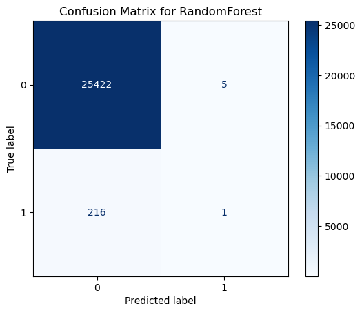

```
Generating Lift plot for RandomForest...
```

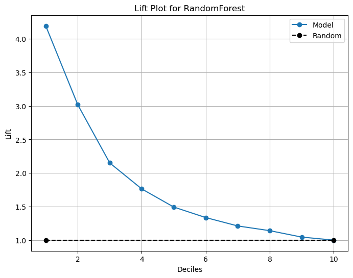

```
Generating Cumulative Gain plot for RandomForest...
```

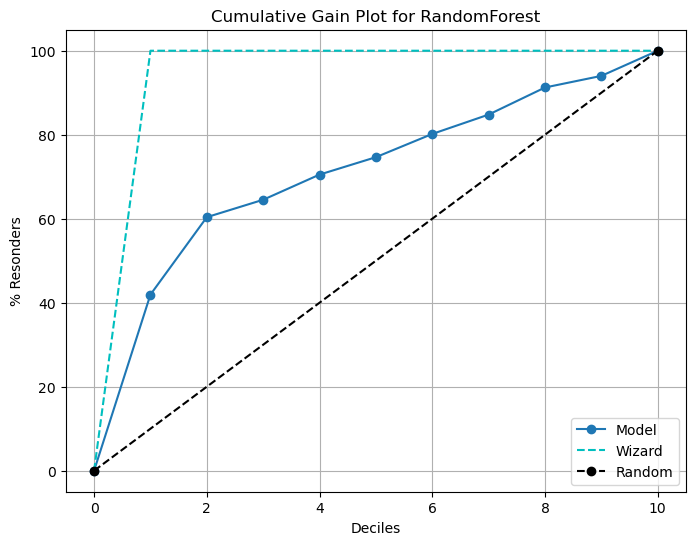

```
Evaluating GradientBoosting on the Test Set...

Test AUC for GradientBoosting: 0.6626653622487363
Confusion Matrix for GradientBoosting:
[[25381    46]
 [  213     4]]
Classification Report for GradientBoosting:
              precision    recall  f1-score   support

         0.0       0.99      1.00      0.99     25427
         1.0       0.08      0.02      0.03       217

    accuracy                           0.99     25644
   macro avg       0.54      0.51      0.51     25644
weighted avg       0.98      0.99      0.99     25644
```

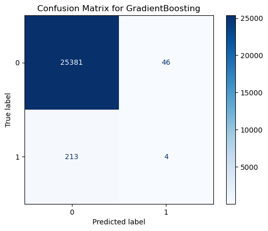

```
Generating Lift plot for GradientBoosting...
```

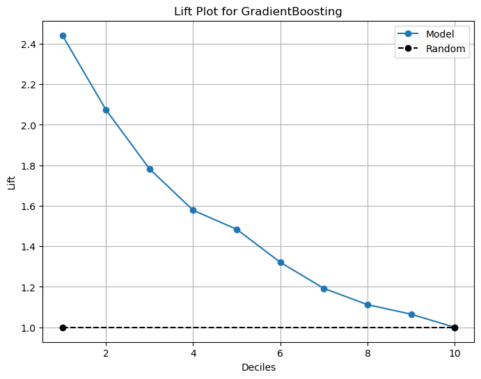

```
Generating Cumulative Gain plot for GradientBoosting...
```

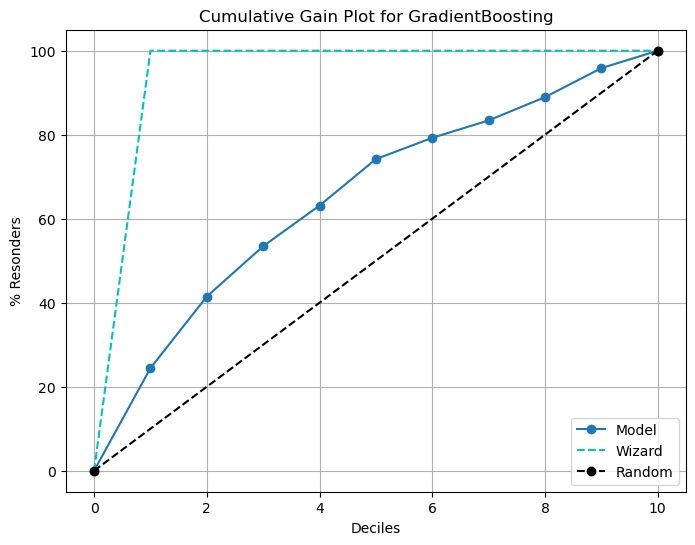

```python
import matplotlib.pyplot as plt
import kds.metrics
from sklearn.metrics import roc_auc_score, confusion_matrix, classification_report, ConfusionMatrixDisplay
from sklearn.ensemble import RandomForestClassifier, GradientBoostingClassifier
from sklearn.neural_network import MLPClassifier

# Models to evaluate
model_classes = {
    "RandomForest": RandomForestClassifier,
    "GradientBoosting": GradientBoostingClassifier
}

# Helper function to remove pipeline prefixes from parameters
def clean_params(params, prefix="classifier__"):
    return {k.replace(prefix, ""): v for k, v in params.items() if k.startswith(prefix)}


# Loop through results and evaluate models
for model_name, result in results.items():
    if model_name in model_classes.keys():
        print(f"\nEvaluating {model_name} on the Test Set...\n")

        # Retrieve the best hyperparameters and selected features
        best_params = result["best_params"]
        cleaned_params = clean_params(best_params)  # Remove pipeline prefixes
        selected_features = result["selected_features"]

        # Filter the test set using selected features
        X_test_selected = X_test[selected_features]

        # Rebuild the model with the cleaned parameters
        model_class = model_classes[model_name]
        best_model = model_class(**cleaned_params)

        # Refit the model on the entire training set (for final evaluation)
        X_train_selected = X_train[selected_features]
        best_model.fit(X_train_selected, y_train)

        # Predict probabilities for the positive class on the test set
        y_test_pred_prob = best_model.predict_proba(X_test_selected)[:, 1]

        # Calculate AUC score
        test_auc = roc_auc_score(y_test, y_test_pred_prob)
        print(f"Test AUC for {model_name}: {test_auc}")

        # Generate confusion matrix
        y_test_pred_class = best_model.predict(X_test_selected)
        cm = confusion_matrix(y_test, y_test_pred_class)
        print(f"Confusion Matrix for {model_name}:\n{cm}")

        # Display classification report
        print(f"Classification Report for {model_name}:\n{classification_report(y_test, y_test_pred_class)}")

        # Plot the confusion matrix
        disp = ConfusionMatrixDisplay(confusion_matrix=cm, display_labels=[0, 1])
        disp.plot(cmap="Blues")
        plt.title(f"Confusion Matrix for {model_name}")
        plt.show()

        # LIFT PLOT
        print(f"Generating Lift plot for {model_name}...\n")

        # Prepare the dataset for plotting Lift curve
        testSet = X_test.copy()
        testSet["target"] = y_test
        testSet["proba target"] = y_test_pred_prob

        # Plot Lift
        plt.figure(figsize=(8, 6))
        kds.metrics.plot_lift(testSet["target"], testSet["proba target"])
        plt.title(f"Lift Plot for {model_name}")
        plt.show()

        # CUMULATIVE GAIN PLOT
        print(f"Generating Cumulative Gain plot for {model_name}...\n")

        # Plot Cumulative Gain
        plt.figure(figsize=(8, 6))
        kds.metrics.plot_cumulative_gain(testSet["target"], testSet["proba target"])
        plt.title(f"Cumulative Gain Plot for {model_name}")
        plt.show()
```

## 6. Final predictions

```python
test_final = pd.read_csv('./data/selection campaign 7662.csv')
```

```python
test_final = pd.merge(test_final, base, how = 'left', on = 'donorID')
test_final = test_final[test_final['date_of_donation'] < "2020-01-01"].copy(deep=True)
```

```python
test_final['amount'] = test_final['amount'].str.replace(',', '.')
test_final['amount'] = test_final['amount'].str.replace(r'\.(?=\d{3})', '', regex=True)
test_final['amount'] = pd.to_numeric(test_final['amount'])
```

#### 6.1 Independant variables

6.1.1 Recency and LOR

```python
recent_donation2 = test_final.groupby('donorID')['date_of_donation'].max().reset_index()
earliest_donation2 = test_final.groupby('donorID')['date_of_donation'].min().reset_index()
```

```python
recent_donation2['Recency'] = (pd.to_datetime("2020-01-01") - recent_donation2['date_of_donation']).dt.days
earliest_donation2['LOR'] = (pd.to_datetime("2020-01-01") - earliest_donation2['date_of_donation']).dt.days / 365
```

```python
recent_donation2 = recent_donation2.drop(columns=['date_of_donation'])
earliest_donation2 = earliest_donation2.drop(columns=['date_of_donation'])
```

```python
test_final = pd.merge(test_final, recent_donation2, how = 'left', on = 'donorID')
test_final = pd.merge(test_final, earliest_donation2, how = 'left', on = 'donorID')
```

6.1.2 Frequency calculation

```python
frequency2 = test_final.groupby('donorID')['amount'].count().reset_index()
# Rename the column for clarity
frequency2.rename(columns={'amount': 'nbr_of_donations'}, inplace=True)
```

```python
test_final = pd.merge(test_final, frequency2, how = 'left', on = 'donorID')
```

6.1.3 Create the independent variable --- sum/avg/max/std of amount donated during the relationship and the last donation amount

```python
sum_donation_amount = test_final.groupby('donorID')['amount'].sum().reset_index()
avg_donation_amount = test_final.groupby('donorID')['amount'].mean().reset_index()
max_donation_amount = test_final.groupby('donorID')['amount'].max().reset_index()
std_donation_amount = test_final.groupby('donorID')['amount'].std().reset_index()
# Rename the column for clarity
sum_donation_amount.rename(columns={'amount': 'sum_donation_amount'}, inplace=True)
avg_donation_amount.rename(columns={'amount': 'avg_donation_amount'}, inplace=True)
max_donation_amount.rename(columns={'amount': 'max_donation_amount'}, inplace=True)
std_donation_amount.rename(columns={'amount': 'std_donation_amount'}, inplace=True)

stats = sum_donation_amount.merge(avg_donation_amount, on='donorID') \
                           .merge(max_donation_amount, on='donorID') \
                           .merge(std_donation_amount, on='donorID')

test_final = pd.merge(test_final, stats, how = 'left', on = 'donorID')

#the last donation amount
last_donation = test_final.loc[test_final.groupby('donorID')['date_of_donation'].idxmax()].reset_index(drop=True)
last_donation.rename(columns={'amount': 'last_donation_amount'}, inplace=True)

last_donation = last_donation[['donorID', 'last_donation_amount']]

test_final = pd.merge(test_final, last_donation, how = 'left', on = 'donorID')
test_final.head()
```

|  | donorID | zipcode | province | region | gender | language | dateOfBirth | campaignID | amount | date_of_donation | date_of_campaign | lettersSent | CostUnit | Recency | LOR | nbr_of_donations | sum_donation_amount | avg_donation_amount | max_donation_amount | std_donation_amount | last_donation_amount |
| --- | --- | --- | --- | --- | --- | --- | --- | --- | --- | --- | --- | --- | --- | --- | --- | --- | --- | --- | --- | --- | --- |
| 0 | D134242 | 3580.0 | Limburg | Flanders | M | NL | 09/28/1966 | 3108.0 | 20.0 | 2012-03-13 | 27/02/2012 | 36 564 | 0,60 € | 2224 | 7.808219 | 2 | 30.0 | 15.0 | 20.0 | 7.071068 | 10.0 |
| 1 | D134242 | 3580.0 | Limburg | Flanders | M | NL | 09/28/1966 | 3663.0 | 10.0 | 2013-11-29 | 20/11/2013 | 35 141 | 0,30 € | 2224 | 7.808219 | 2 | 30.0 | 15.0 | 20.0 | 7.071068 | 10.0 |
| 2 | D126503 | 4250.0 | Liege | Wallonia | M | FR | 10/20/1949 | 3941.0 | 50.0 | 2014-12-28 | 25/12/2014 | 37 833 | 0,50 € | 1830 | 5.013699 | 1 | 50.0 | 50.0 | 50.0 | NaN | 50.0 |
| 3 | D104392 | 4820.0 | Liege | Wallonia | F | FR | 05/03/1974 | 3941.0 | 50.0 | 2014-12-29 | 25/12/2014 | 37 833 | 0,50 € | 1829 | 5.010959 | 1 | 50.0 | 50.0 | 50.0 | NaN | 50.0 |
| 4 | D105905 | 8370.0 | West Flanders | Flanders | M | NL | 09/18/1970 | NaN | 55.0 | 2016-11-21 | NaN | NaN | NaN | 33 | 3.112329 | 3 | 210.0 | 70.0 | 100.0 | 25.980762 | 55.0 |

6.1.4 Create the independent variable --- freq and sum/avg/std of amount donated during the last 6m/1y/3y

```python
reference_date2 = pd.to_datetime("2020-01-01")
test_final['date_of_donation'] = pd.to_datetime(test_final['date_of_donation'])
three_m = reference_date2 - pd.DateOffset(months=3)
six_m = reference_date2 - pd.DateOffset(months=6)
one_y = reference_date2 - pd.DateOffset(years=1)
three_y = reference_date2 - pd.DateOffset(years=3)
five_y = reference_date2 - pd.DateOffset(years=5)


def calculate(test_final, start_date, end_date):
    period = test_final[(test_final['date_of_donation'] >= start_date) & (test_final['date_of_donation'] <= end_date)]
    stats1 = period.groupby('donorID').agg(
        sum_monetary=('amount', 'sum'),
        avg_monetary=('amount', 'mean'),
        std_monetary=('amount', 'std'),
        freq=('amount', 'count')
    ).reset_index()
    return stats1

stats1_3m = calculate(test_final, three_m, reference_date2)
stats1_6m = calculate(test_final, six_m, reference_date2)
stats1_1y = calculate(test_final, one_y, reference_date2)
stats1_3y = calculate(test_final, three_y, reference_date2)
stats1_5y = calculate(test_final, five_y, reference_date2)


stats1_3m = stats1_3m.rename(columns={
    'sum_monetary': 'sum_monetary_3m',
    'avg_monetary': 'avg_monetary_3m',
    'std_monetary': 'std_monetary_3m',
    'freq': 'freq_3m'
})
stats1_6m = stats1_6m.rename(columns={
    'sum_monetary': 'sum_monetary_6m',
    'avg_monetary': 'avg_monetary_6m',
    'std_monetary': 'std_monetary_6m',
    'freq': 'freq_6m'
})
stats1_1y = stats1_1y.rename(columns={
    'sum_monetary': 'sum_monetary_1y',
    'avg_monetary': 'avg_monetary_1y',
    'std_monetary': 'std_monetary_1y',
    'freq': 'freq_1y'
})
stats1_3y = stats1_3y.rename(columns={
    'sum_monetary': 'sum_monetary_3y',
    'avg_monetary': 'avg_monetary_3y',
    'std_monetary': 'std_monetary_3y',
    'freq': 'freq_3y'
})
stats1_5y = stats1_5y.rename(columns={
    'sum_monetary': 'sum_monetary_5y',
    'avg_monetary': 'avg_monetary_5y',
    'std_monetary': 'std_monetary_5y',
    'freq': 'freq_5y'
})

stats1_5y = pd.merge(stats1_5y, stats1_3y, how = 'left', on='donorID')
stats1_5y = pd.merge(stats1_5y, stats1_1y, how = 'left', on='donorID')
stats1_5y = pd.merge(stats1_5y, stats1_6m, how = 'left', on='donorID')
stats1_5y = pd.merge(stats1_5y, stats1_3m, how = 'left', on='donorID')
```

```python
test_final = pd.merge(test_final, stats1_5y, how = 'left', on = 'donorID')
test_final.head()
```

|  | donorID | zipcode | province | region | gender | language | dateOfBirth | campaignID | amount | date_of_donation | date_of_campaign | lettersSent | CostUnit | Recency | LOR | nbr_of_donations | sum_donation_amount | avg_donation_amount | max_donation_amount | std_donation_amount | last_donation_amount | sum_monetary_5y | avg_monetary_5y | std_monetary_5y | freq_5y | sum_monetary_3y | avg_monetary_3y | std_monetary_3y | freq_3y | … |
| --- | --- | --- | --- | --- | --- | --- | --- | --- | --- | --- | --- | --- | --- | --- | --- | --- | --- | --- | --- | --- | --- | --- | --- | --- | --- | --- | --- | --- | --- | --- |
| 0 | D134242 | 3580.0 | Limburg | Flanders | M | NL | 09/28/1966 | 3108.0 | 20.0 | 2012-03-13 | 27/02/2012 | 36 564 | 0,60 € | 2224 | 7.808219 | 2 | 30.0 | 15.0 | 20.0 | 7.071068 | 10.0 | NaN | NaN | NaN | NaN | NaN | NaN | NaN | NaN | … |
| 1 | D134242 | 3580.0 | Limburg | Flanders | M | NL | 09/28/1966 | 3663.0 | 10.0 | 2013-11-29 | 20/11/2013 | 35 141 | 0,30 € | 2224 | 7.808219 | 2 | 30.0 | 15.0 | 20.0 | 7.071068 | 10.0 | NaN | NaN | NaN | NaN | NaN | NaN | NaN | NaN | … |
| 2 | D126503 | 4250.0 | Liege | Wallonia | M | FR | 10/20/1949 | 3941.0 | 50.0 | 2014-12-28 | 25/12/2014 | 37 833 | 0,50 € | 1830 | 5.013699 | 1 | 50.0 | 50.0 | 50.0 | NaN | 50.0 | NaN | NaN | NaN | NaN | NaN | NaN | NaN | NaN | … |
| 3 | D104392 | 4820.0 | Liege | Wallonia | F | FR | 05/03/1974 | 3941.0 | 50.0 | 2014-12-29 | 25/12/2014 | 37 833 | 0,50 € | 1829 | 5.010959 | 1 | 50.0 | 50.0 | 50.0 | NaN | 50.0 | NaN | NaN | NaN | NaN | NaN | NaN | NaN | NaN | … |
| 4 | D105905 | 8370.0 | West Flanders | Flanders | M | NL | 09/18/1970 | NaN | 55.0 | 2016-11-21 | NaN | NaN | NaN | 33 | 3.112329 | 3 | 210.0 | 70.0 | 100.0 | 25.980762 | 55.0 | 210.0 | 70.0 | 25.980762 | 3.0 | 155.0 | 77.5 | 31.819805 | 2.0 | … |

Seasonality and Weekday

```python
#Seasonality
campaign2 = test_final[test_final['date_of_campaign'].notna()]
campaign2['date_of_campaign'] = pd.to_datetime(campaign2['date_of_campaign'], format='%d/%m/%Y', errors='coerce')
campaign2['month'] = campaign2['date_of_campaign'].dt.month

def get_season(month):
    if month in [12, 1, 2]:
        return 'Winter'
    elif month in [3, 4, 5]:
        return 'Spring'
    elif month in [6, 7, 8]:
        return 'Summer'
    elif month in [9, 10, 11]:
        return 'Fall'

campaign2['season'] = campaign2['month'].apply(get_season)
seasonality = campaign2.groupby(['donorID', 'season']).size().reset_index(name='donation_count')
seasonality = seasonality.pivot(index='donorID', columns='season', values='donation_count').fillna(0)
seasonality.reset_index(inplace=True)

seasonality = seasonality.rename(columns={
    'Fall': 'Fall_campaign',
    'Spring': 'Spring_campaign',
    'Summer': 'Summer_campaign',
    'Winter': 'Winter_campaign'})

test_final = pd.merge(test_final, seasonality, how = 'left', on='donorID')
```

```python
test_final['date_of_donation'] = pd.to_datetime(test_final['date_of_donation'], errors='coerce')

#Seasonality
test_final['month'] = test_final['date_of_donation'].dt.month

def get_season(month):
    if month in [12, 1, 2]:
        return 'Winter'
    elif month in [3, 4, 5]:
        return 'Spring'
    elif month in [6, 7, 8]:
        return 'Summer'
    elif month in [9, 10, 11]:
        return 'Fall'

test_final['season'] = test_final['month'].apply(get_season)
seasonality = test_final.groupby(['donorID', 'season']).size().reset_index(name='donation_count')
seasonality = seasonality.pivot(index='donorID', columns='season', values='donation_count').fillna(0)
seasonality.reset_index(inplace=True)
test_final = pd.merge(test_final, seasonality, how = 'left', on='donorID')


#Weekday
test_final['day_of_week'] = test_final['date_of_donation'].dt.dayofweek
test_final['is_monday'] = test_final['day_of_week'].apply(lambda x: 1 if x == 0 else 0)
test_final['is_tuesday'] = test_final['day_of_week'].apply(lambda x: 1 if x == 1 else 0)
test_final['is_wednesday'] = test_final['day_of_week'].apply(lambda x: 1 if x == 2 else 0)
test_final['is_thursday'] = test_final['day_of_week'].apply(lambda x: 1 if x == 3 else 0)
test_final['is_friday'] = test_final['day_of_week'].apply(lambda x: 1 if x == 4 else 0)
test_final['is_saturday'] = test_final['day_of_week'].apply(lambda x: 1 if x == 5 else 0)
test_final['is_sunday'] = test_final['day_of_week'].apply(lambda x: 1 if x == 6 else 0)

Monday = test_final.groupby('donorID')['is_monday'].sum().reset_index()
Tuesday = test_final.groupby('donorID')['is_tuesday'].sum().reset_index()
Wednesday = test_final.groupby('donorID')['is_wednesday'].sum().reset_index()
Thursday = test_final.groupby('donorID')['is_thursday'].sum().reset_index()
Friday = test_final.groupby('donorID')['is_friday'].sum().reset_index()
Saturday = test_final.groupby('donorID')['is_saturday'].sum().reset_index()
Sunday = test_final.groupby('donorID')['is_sunday'].sum().reset_index()

# Rename the column for clarity
Monday.rename(columns={'is_monday': 'donate_on_monday'}, inplace=True)
Tuesday.rename(columns={'is_tuesday': 'donate_on_tuesday'}, inplace=True)
Wednesday.rename(columns={'is_wednesday': 'donate_on_wednesday'}, inplace=True)
Thursday.rename(columns={'is_thursday': 'donate_on_thursday'}, inplace=True)
Friday.rename(columns={'is_friday': 'donate_on_friday'}, inplace=True)
Saturday.rename(columns={'is_saturday': 'donate_on_saturday'}, inplace=True)
Sunday.rename(columns={'is_sunday': 'donate_on_sunday'}, inplace=True)

Weekday = Monday.merge(Tuesday, on='donorID') \
            .merge(Wednesday, on='donorID')\
            .merge(Thursday, on='donorID')\
            .merge(Friday, on='donorID')\
            .merge(Saturday, on='donorID')\
            .merge(Sunday, on='donorID')
Weekday.head()
```

|  | donorID | donate_on_monday | donate_on_tuesday | donate_on_wednesday | donate_on_thursday | donate_on_friday | donate_on_saturday | donate_on_sunday |
| --- | --- | --- | --- | --- | --- | --- | --- | --- |
| 0 | D100001 | 2 | 1 | 1 | 2 | 4 | 2 | 0 |
| 1 | D100003 | 3 | 2 | 0 | 2 | 3 | 1 | 1 |
| 2 | D100004 | 4 | 3 | 4 | 1 | 7 | 5 | 2 |
| 3 | D100006 | 0 | 1 | 0 | 0 | 0 | 0 | 0 |
| 4 | D100009 | 3 | 1 | 3 | 1 | 2 | 3 | 6 |

```python
test_final = pd.merge(test_final, Weekday, how = 'left', on='donorID')
```

6.1.5 Campaign related variables

```python
donations_outside_campaign = test_final[test_final['campaignID'].isnull()]
outside_campaign_count = donations_outside_campaign.groupby('donorID').size().reset_index(name='outside_campaign_donate')
test_final = pd.merge(test_final, outside_campaign_count, how = 'left', on='donorID')
```

```python
campaign2 = test_final[test_final['date_of_campaign'].notna()]
campaign2['date_of_campaign'] = pd.to_datetime(campaign2['date_of_campaign'], format='%d/%m/%Y', errors='coerce')

recent_campaign2 = campaign2.groupby('donorID')['date_of_campaign'].max().reset_index()
recent_campaign2['recency_campaign'] = (reference_date2 - recent_campaign2['date_of_campaign']).dt.days
recent_campaign2 = recent_campaign2[['donorID','recency_campaign']]

test_final = pd.merge(test_final, recent_campaign2, how = 'left', on='donorID')
```

6.1.6 Campaign_freq_3m/6m/1y/3y/5y

```python
def calculate_campaign2_frequency(campaign2, start_date, end_date):
    # Filter donations within the given period
    period = campaign2[(campaign2['date_of_campaign'] >= start_date) & (campaign2['date_of_campaign'] <= end_date)]

    # Group by 'donorID' and count the number of donations in that period
    campaign_freq = period.groupby('donorID').size().reset_index(name='campaign_freq')

    return campaign_freq

freq_3m = calculate_campaign2_frequency(campaign2, three_m, reference_date2)
freq_6m = calculate_campaign2_frequency(campaign2, six_m, reference_date2)
freq_1y = calculate_campaign2_frequency(campaign2, one_y, reference_date2)
freq_3y = calculate_campaign2_frequency(campaign2, three_y, reference_date2)
freq_5y = calculate_campaign2_frequency(campaign2, five_y, reference_date2)

freq_3m = freq_3m.rename(columns={'campaign_freq': 'campaign_freq_3m'})
freq_6m = freq_6m.rename(columns={'campaign_freq': 'campaign_freq_6m'})
freq_1y = freq_1y.rename(columns={'campaign_freq': 'campaign_freq_1y'})
freq_3y = freq_3y.rename(columns={'campaign_freq': 'campaign_freq_3y'})
freq_5y = freq_5y.rename(columns={'campaign_freq': 'campaign_freq_5y'})

freq_5y = pd.merge(freq_5y, freq_3y, how = 'left', on='donorID')
freq_5y = pd.merge(freq_5y, freq_1y, how = 'left', on='donorID')
freq_5y = pd.merge(freq_5y, freq_6m, how = 'left', on='donorID')
freq_5y = pd.merge(freq_5y, freq_3m, how = 'left', on='donorID')

test_final = pd.merge(test_final, freq_5y, how = 'left', on='donorID')
```

```python
#Weekday
campaign2['day_of_week'] = campaign2['date_of_campaign'].dt.dayofweek

campaign2['is_monday'] = campaign2['day_of_week'].apply(lambda x: 1 if x == 0 else 0)
campaign2['is_tuesday'] = campaign2['day_of_week'].apply(lambda x: 1 if x == 1 else 0)
campaign2['is_wednesday'] = campaign2['day_of_week'].apply(lambda x: 1 if x == 2 else 0)
campaign2['is_thursday'] = campaign2['day_of_week'].apply(lambda x: 1 if x == 3 else 0)
campaign2['is_friday'] = campaign2['day_of_week'].apply(lambda x: 1 if x == 4 else 0)
campaign2['is_saturday'] = campaign2['day_of_week'].apply(lambda x: 1 if x == 5 else 0)
campaign2['is_sunday'] = campaign2['day_of_week'].apply(lambda x: 1 if x == 6 else 0)

Monday = campaign2.groupby('donorID')['is_monday'].sum().reset_index()
Tuesday = campaign2.groupby('donorID')['is_tuesday'].sum().reset_index()
Wednesday = campaign2.groupby('donorID')['is_wednesday'].sum().reset_index()
Thursday = campaign2.groupby('donorID')['is_thursday'].sum().reset_index()
Friday = campaign2.groupby('donorID')['is_friday'].sum().reset_index()
Saturday = campaign2.groupby('donorID')['is_saturday'].sum().reset_index()
Sunday = campaign2.groupby('donorID')['is_sunday'].sum().reset_index()

# Rename the column for clarity
Monday.rename(columns={'is_monday': 'campaign_on_monday'}, inplace=True)
Tuesday.rename(columns={'is_tuesday': 'campaign_on_tuesday'}, inplace=True)
Wednesday.rename(columns={'is_wednesday': 'campaign_on_wednesday'}, inplace=True)
Thursday.rename(columns={'is_thursday': 'campaign_on_thursday'}, inplace=True)
Friday.rename(columns={'is_friday': 'campaign_on_friday'}, inplace=True)
Saturday.rename(columns={'is_saturday': 'campaign_on_saturday'}, inplace=True)
Sunday.rename(columns={'is_sunday': 'campaign_on_sunday'}, inplace=True)

Weekday = Monday.merge(Tuesday, on='donorID') \
            .merge(Wednesday, on='donorID')\
            .merge(Thursday, on='donorID')\
            .merge(Friday, on='donorID')\
            .merge(Saturday, on='donorID')\
            .merge(Sunday, on='donorID')
Weekday.head()

test_final = pd.merge(test_final, Weekday, how = 'left', on='donorID')
```

6.1.7 Maximum and minimum length between date_of_donation and date_of_campaign per donor

```python
test_final['date_of_donation'] = pd.to_datetime(test_final['date_of_donation'], format='%d/%m/%Y', errors='coerce')
test_final['date_of_campaign'] = pd.to_datetime(test_final['date_of_campaign'],  format='%d/%m/%Y', errors='coerce')

test_final['date_diff'] = (test_final['date_of_donation'] - test_final['date_of_campaign']).dt.days

max_diff = test_final.groupby('donorID')['date_diff'].max().reset_index()
min_diff = test_final.groupby('donorID')['date_diff'].min().reset_index()

# Rename the column for clarity
max_diff.rename(columns={'date_diff': 'max_date_diff'}, inplace=True)
min_diff.rename(columns={'date_diff': 'min_date_diff'}, inplace=True)

test_final = pd.merge(test_final, max_diff, how = 'left', on='donorID')
test_final = pd.merge(test_final, min_diff, how = 'left', on='donorID')
```

6.1.8 Create the independent variable --- age group

```python
test_final['dateOfBirth'] = pd.to_datetime(test_final['dateOfBirth'], format='%m/%d/%Y')

# Extract the birth year
test_final['birth_year'] = test_final['dateOfBirth'].dt.year
test_final['birth_year'].head()

test_final['age'] = 2020 - test_final['birth_year']

# Age group
test_final['age_group'] = test_final['age'] // 10 * 10
test_final.drop(columns = ['dateOfBirth', 'birth_year', 'age'], inplace = True)
```

6.1.9 Donation amount over or equal to 30

```python
test_final['amount_over_30'] = (test_final['amount'] >= 30).astype(int)

# Group by donor and calculate the sum of donations >= 30
test_final_donations_over_30 = test_final.groupby('donorID')['amount_over_30'].sum()

# Convert back to a DataFrame if needed
test_final_donations_over_30 = test_final_donations_over_30.reset_index(name='donations_over_30')
```

```python
test_final = pd.merge(test_final, test_final_donations_over_30, how = 'left', on = 'donorID')
```

```python
test_final= test_final[['donorID', 'province', 'region', 'gender', 'language','age_group',
                'Recency', 'LOR','nbr_of_donations', 'sum_donation_amount', 'avg_donation_amount','max_donation_amount', 'std_donation_amount',
                'sum_monetary_5y','avg_monetary_5y', 'std_monetary_5y', 'freq_5y',
                  'sum_monetary_3y','avg_monetary_3y', 'std_monetary_3y', 'freq_3y',
                  'sum_monetary_1y','avg_monetary_1y', 'std_monetary_1y', 'freq_1y',
                  'sum_monetary_6m','avg_monetary_6m', 'std_monetary_6m', 'freq_6m',
                  'sum_monetary_3m','avg_monetary_3m', 'std_monetary_3m', 'freq_3m',
                  'Fall', 'Spring', 'Summer', 'Winter',
                    'donate_on_monday','donate_on_tuesday', 'donate_on_wednesday', 'donate_on_thursday',
                    'donate_on_friday', 'donate_on_saturday', 'donate_on_sunday',
                    'outside_campaign_donate','recency_campaign',
                    'campaign_freq_5y', 'campaign_freq_3y', 'campaign_freq_1y', 'campaign_freq_6m', 'campaign_freq_3m',
                    'Fall_campaign', 'Spring_campaign', 'Summer_campaign', 'Winter_campaign',
                    'campaign_on_monday', 'campaign_on_tuesday','campaign_on_wednesday', 'campaign_on_thursday',
                    'campaign_on_friday','campaign_on_saturday', 'campaign_on_sunday',
                    'max_date_diff', 'min_date_diff',
                     'donations_over_30']]
test_final = test_final.drop_duplicates(subset='donorID', keep='first')
test_final.head()
```

|  | donorID | province | region | gender | language | age_group | Recency | LOR | nbr_of_donations | sum_donation_amount | avg_donation_amount | max_donation_amount | std_donation_amount | sum_monetary_5y | avg_monetary_5y | std_monetary_5y | freq_5y | sum_monetary_3y | avg_monetary_3y | std_monetary_3y | freq_3y | sum_monetary_1y | avg_monetary_1y | std_monetary_1y | freq_1y | sum_monetary_6m | avg_monetary_6m | std_monetary_6m | freq_6m | … |
| --- | --- | --- | --- | --- | --- | --- | --- | --- | --- | --- | --- | --- | --- | --- | --- | --- | --- | --- | --- | --- | --- | --- | --- | --- | --- | --- | --- | --- | --- | --- |
| 0 | D134242 | Limburg | Flanders | M | NL | 50 | 2224 | 7.808219 | 2 | 30.00 | 15.000 | 20.0 | 7.071068 | NaN | NaN | NaN | NaN | NaN | NaN | NaN | NaN | NaN | NaN | NaN | NaN | NaN | NaN | NaN | NaN | … |
| 2 | D126503 | Liege | Wallonia | M | FR | 70 | 1830 | 5.013699 | 1 | 50.00 | 50.000 | 50.0 | NaN | NaN | NaN | NaN | NaN | NaN | NaN | NaN | NaN | NaN | NaN | NaN | NaN | NaN | NaN | NaN | NaN | … |
| 3 | D104392 | Liege | Wallonia | F | FR | 40 | 1829 | 5.010959 | 1 | 50.00 | 50.000 | 50.0 | NaN | NaN | NaN | NaN | NaN | NaN | NaN | NaN | NaN | NaN | NaN | NaN | NaN | NaN | NaN | NaN | NaN | … |
| 4 | D105905 | West Flanders | Flanders | M | NL | 50 | 33 | 3.112329 | 3 | 210.00 | 70.000 | 100.0 | 25.980762 | 210.0 | 70.0 | 25.980762 | 3.0 | 155.0 | 77.5 | 31.819805 | 2.0 | 155.0 | 77.5 | 31.819805 | 2.0 | 55.0 | 55.0 | NaN | 1.0 | … |
| 7 | D120506 | West Flanders | Flanders | M | NL | 40 | 2922 | 11.339726 | 5 | 61.89 | 12.378 | 12.5 | 0.216610 | NaN | NaN | NaN | NaN | NaN | NaN | NaN | NaN | NaN | NaN | NaN | NaN | NaN | NaN | NaN | NaN | … |

```python
test_profile = test_final
```

#### 6.2 Data correction and value transformation

```python
test_final.isna().sum()
```

```
donorID                        0
province                       0
region                         0
gender                        23
language                       0
age_group                      0
Recency                        0
LOR                            0
nbr_of_donations               0
sum_donation_amount            0
avg_donation_amount            0
max_donation_amount            0
std_donation_amount         9948
sum_monetary_5y            15069
avg_monetary_5y            15069
std_monetary_5y            21685
freq_5y                    15069
sum_monetary_3y            20511
avg_monetary_3y            20511
std_monetary_3y            24222
freq_3y                    20511
sum_monetary_1y            24003
avg_monetary_1y            24003
std_monetary_1y            25686
freq_1y                    24003
sum_monetary_6m            25370
avg_monetary_6m            25370
std_monetary_6m            26326
freq_6m                    25370
sum_monetary_3m            25857
avg_monetary_3m            25857
std_monetary_3m            26439
freq_3m                    25857
Fall                           0
Spring                         0
Summer                         0
Winter                         0
donate_on_monday               0
donate_on_tuesday              0
donate_on_wednesday            0
```

[output cut: 11 more lines]

```
Fall_campaign                722
Spring_campaign              722
Summer_campaign              722
Winter_campaign              722
campaign_on_monday           722
campaign_on_tuesday          722
campaign_on_wednesday        722
campaign_on_thursday         722
campaign_on_friday           722
campaign_on_saturday         722
campaign_on_sunday           722
max_date_diff                722
min_date_diff                722
donations_over_30              0
dtype: int64
```

##### 6.2.1 Data Correction

```python
#when the std is NAN while the avg, sum and max for this donner is not null, it means this donner only donated one time, so we assign 0 to NAN
#when the sum, avg, std are all NAN for one donner during the certain period, it means this person didn't donate during this period, so we also assign 0 to NAN
replace_missing = ['std_donation_amount',
                   'sum_monetary_5y', 'avg_monetary_5y', 'std_monetary_5y', 'freq_5y',
                   'sum_monetary_3y', 'avg_monetary_3y', 'std_monetary_3y', 'freq_3y',
                   'sum_monetary_1y', 'avg_monetary_1y', 'std_monetary_1y', 'freq_1y',
                   'sum_monetary_6m', 'avg_monetary_6m', 'std_monetary_6m', 'freq_6m',
                   'sum_monetary_3m', 'avg_monetary_3m', 'std_monetary_3m', 'freq_3m',
                   'outside_campaign_donate','recency_campaign',
                   'campaign_freq_5y', 'campaign_freq_3y', 'campaign_freq_1y', 'campaign_freq_6m', 'campaign_freq_3m']

for col in replace_missing:
    test_final[col].fillna(0, inplace=True);
```

```python
# for the gender has missing values, it means these donors do not want to give information on their gender or do not answer
test_final['gender'].fillna('NO_ANSWER', inplace=True)
```

Outliers

```python
for col in Winsorize_variable:
    Q3 = test_final[col].quantile(0.99)  # 99th percentile

    upper_threshold = Q3

    # Apply winsorizationupper_threshold)
    test_final[col] = test_final[col].clip(upper = upper_threshold)
```

##### 6.2.2 Value transformation

Discretization

```python
#For Recency, a lower value is better (more recent), so we reverse the labels ([5, 4, 3, 2, 1]).
test_final['Recency_Score'] = pd.cut(test_final['Recency'], 5, labels=[5, 4, 3, 2, 1])
test_final['Recency_Score_campaign'] = pd.cut(test_final['recency_campaign'], 5, labels=[5, 4, 3, 2, 1])
```

```python
bin_variable = ['LOR', 'nbr_of_donations', 'Fall', 'Spring', 'Summer', 'Winter',
                'donate_on_monday', 'donate_on_tuesday', 'donate_on_wednesday',
                'donate_on_thursday', 'donate_on_friday','donate_on_saturday', 'donate_on_sunday',
                'outside_campaign_donate']
for col in bin_variable:
    test_final[f'{col}_Score'] = pd.cut(test_final[col], 5, labels=[1, 2, 3, 4, 5])
```

```python
test_final = test_final.drop(['Recency', 'LOR', 'nbr_of_donations',
                            'Fall', 'Spring', 'Summer', 'Winter',
                            'donate_on_monday', 'donate_on_tuesday','donate_on_wednesday', 'donate_on_thursday',
                            'donate_on_friday','donate_on_saturday', 'donate_on_sunday',
                            'recency_campaign', 'outside_campaign_donate'], axis= 1)
```

```python
no_join = ['Fall_campaign', 'Spring_campaign', 'Summer_campaign', 'Winter_campaign',
                    'campaign_on_monday', 'campaign_on_tuesday','campaign_on_wednesday', 'campaign_on_thursday',
                    'campaign_on_friday','campaign_on_saturday', 'campaign_on_sunday']
```

```python
test_final['Fall_campaign'].isna().sum()
```

```
722
```

```python
labels = ['low_frequency', 'medium_frequency', 'high_frequency']
```

```python
for col in no_join:
    test_final[f'{col}_Score'] = pd.cut(test_final[col], 3, labels=labels)
```

```python
test_final.columns
```

```
Index(['donorID', 'province', 'region', 'gender', 'language', 'age_group',
       'sum_donation_amount', 'avg_donation_amount', 'max_donation_amount',
       'std_donation_amount', 'sum_monetary_5y', 'avg_monetary_5y',
       'std_monetary_5y', 'freq_5y', 'sum_monetary_3y', 'avg_monetary_3y',
       'std_monetary_3y', 'freq_3y', 'sum_monetary_1y', 'avg_monetary_1y',
       'std_monetary_1y', 'freq_1y', 'sum_monetary_6m', 'avg_monetary_6m',
       'std_monetary_6m', 'freq_6m', 'sum_monetary_3m', 'avg_monetary_3m',
       'std_monetary_3m', 'freq_3m', 'campaign_freq_5y', 'campaign_freq_3y',
       'campaign_freq_1y', 'campaign_freq_6m', 'campaign_freq_3m',
       'Fall_campaign', 'Spring_campaign', 'Summer_campaign',
       'Winter_campaign', 'campaign_on_monday', 'campaign_on_tuesday',
       'campaign_on_wednesday', 'campaign_on_thursday', 'campaign_on_friday',
       'campaign_on_saturday', 'campaign_on_sunday', 'max_date_diff',
       'min_date_diff', 'donations_over_30', 'Recency_Score',
       'Recency_Score_campaign', 'LOR_Score', 'nbr_of_donations_Score',
       'Fall_Score', 'Spring_Score', 'Summer_Score', 'Winter_Score',
       'donate_on_monday_Score', 'donate_on_tuesday_Score',
       'donate_on_wednesday_Score', 'donate_on_thursday_Score',
       'donate_on_friday_Score', 'donate_on_saturday_Score',
       'donate_on_sunday_Score', 'outside_campaign_donate_Score',
       'Fall_campaign_Score', 'Spring_campaign_Score', 'Summer_campaign_Score',
       'Winter_campaign_Score', 'campaign_on_monday_Score',
       'campaign_on_tuesday_Score', 'campaign_on_wednesday_Score',
       'campaign_on_thursday_Score', 'campaign_on_friday_Score',
       'campaign_on_saturday_Score', 'campaign_on_sunday_Score'],
      dtype='object')
```

```python
replace_missing = ['Fall_campaign_Score', 'Spring_campaign_Score', 'Summer_campaign_Score',
       'Winter_campaign_Score', 'campaign_on_monday_Score',
       'campaign_on_tuesday_Score', 'campaign_on_wednesday_Score',
       'campaign_on_thursday_Score', 'campaign_on_friday_Score',
       'campaign_on_saturday_Score', 'campaign_on_sunday_Score']

for col in replace_missing:
    test_final[col] = test_final[col].replace('NAN', 'NO_JOIN')
```

```python
test_final.drop(columns=no_join, inplace=True)
```

```python
no_join1 = ['max_date_diff', 'min_date_diff']
labels = ['low_diff', 'medium_diff', 'high_diff']

# Apply binning on train and validation
for col in no_join1:
    test_final[f'{col}_Score'] = pd.cut(test_final[col], 3, labels=labels)

# Replace 'NAN' string in *_Score columns with 'NO_JOIN'
replace_missing = ['max_date_diff_Score', 'min_date_diff_Score']
for col in replace_missing:
    test_final[col] = test_final[col].replace('NAN', 'NO_JOIN')

# Drop the original 'max_date_diff' and 'min_date_diff' columns
test_final.drop(columns=no_join1, inplace=True)
```

Dummy coding

```python
test_final = pd.get_dummies(test_final, columns=['gender', 'language', 'province', 'region',
                                              'Fall_campaign_Score', 'Spring_campaign_Score', 'Summer_campaign_Score',
                                               'Winter_campaign_Score', 'campaign_on_monday_Score',
                                                'campaign_on_tuesday_Score', 'campaign_on_wednesday_Score',
                                                   'campaign_on_thursday_Score', 'campaign_on_friday_Score',
                                                   'campaign_on_saturday_Score', 'campaign_on_sunday_Score',
                                                       'max_date_diff_Score', 'min_date_diff_Score'], drop_first=True)
```

```python
test_final.columns
```

```
Index(['donorID', 'age_group', 'sum_donation_amount', 'avg_donation_amount',
       'max_donation_amount', 'std_donation_amount', 'sum_monetary_5y',
       'avg_monetary_5y', 'std_monetary_5y', 'freq_5y', 'sum_monetary_3y',
       'avg_monetary_3y', 'std_monetary_3y', 'freq_3y', 'sum_monetary_1y',
       'avg_monetary_1y', 'std_monetary_1y', 'freq_1y', 'sum_monetary_6m',
       'avg_monetary_6m', 'std_monetary_6m', 'freq_6m', 'sum_monetary_3m',
       'avg_monetary_3m', 'std_monetary_3m', 'freq_3m', 'campaign_freq_5y',
       'campaign_freq_3y', 'campaign_freq_1y', 'campaign_freq_6m',
       'campaign_freq_3m', 'donations_over_30', 'Recency_Score',
       'Recency_Score_campaign', 'LOR_Score', 'nbr_of_donations_Score',
       'Fall_Score', 'Spring_Score', 'Summer_Score', 'Winter_Score',
       'donate_on_monday_Score', 'donate_on_tuesday_Score',
       'donate_on_wednesday_Score', 'donate_on_thursday_Score',
       'donate_on_friday_Score', 'donate_on_saturday_Score',
       'donate_on_sunday_Score', 'outside_campaign_donate_Score', 'gender_M',
       'gender_NO_ANSWER', 'language_FR', 'language_NL', 'province_Antwerp',
       'province_Brussels', 'province_East Flanders',
       'province_Flemish Brabant', 'province_Hainaut', 'province_Liege',
       'province_Limburg', 'province_Luxembourg', 'province_Missing',
       'province_Namur', 'province_Walloon Brabant', 'province_West Flanders',
       'region_Flanders', 'region_Missing', 'region_Wallonia',
       'Fall_campaign_Score_medium_frequency',
       'Fall_campaign_Score_high_frequency',
       'Spring_campaign_Score_medium_frequency',
       'Spring_campaign_Score_high_frequency',
       'Summer_campaign_Score_medium_frequency',
       'Summer_campaign_Score_high_frequency',
       'Winter_campaign_Score_medium_frequency',
       'Winter_campaign_Score_high_frequency',
       'campaign_on_monday_Score_medium_frequency',
       'campaign_on_monday_Score_high_frequency',
       'campaign_on_tuesday_Score_medium_frequency',
       'campaign_on_tuesday_Score_high_frequency',
       'campaign_on_wednesday_Score_medium_frequency',
       'campaign_on_wednesday_Score_high_frequency',
       'campaign_on_thursday_Score_medium_frequency',
       'campaign_on_thursday_Score_high_frequency',
       'campaign_on_friday_Score_medium_frequency',
       'campaign_on_friday_Score_high_frequency',
       'campaign_on_saturday_Score_medium_frequency',
       'campaign_on_saturday_Score_high_frequency',
       'campaign_on_sunday_Score_medium_frequency',
       'campaign_on_sunday_Score_high_frequency',
       'max_date_diff_Score_medium_diff', 'max_date_diff_Score_high_diff',
       'min_date_diff_Score_medium_diff', 'min_date_diff_Score_high_diff'],
      dtype='object')
```

```python
dummy_column = ['gender_M',
       'gender_NO_ANSWER', 'language_FR', 'language_NL', 'province_Antwerp',
       'province_Brussels', 'province_East Flanders',
       'province_Flemish Brabant', 'province_Hainaut', 'province_Liege',
       'province_Limburg', 'province_Luxembourg', 'province_Missing',
       'province_Namur', 'province_Walloon Brabant', 'province_West Flanders',
       'region_Flanders', 'region_Missing', 'region_Wallonia',
       'Fall_campaign_Score_medium_frequency',
       'Fall_campaign_Score_high_frequency',
       'Spring_campaign_Score_medium_frequency',
       'Spring_campaign_Score_high_frequency',
       'Summer_campaign_Score_medium_frequency',
       'Summer_campaign_Score_high_frequency',
       'Winter_campaign_Score_medium_frequency',
       'Winter_campaign_Score_high_frequency',
       'campaign_on_monday_Score_medium_frequency',
       'campaign_on_monday_Score_high_frequency',
       'campaign_on_tuesday_Score_medium_frequency',
       'campaign_on_tuesday_Score_high_frequency',
       'campaign_on_wednesday_Score_medium_frequency',
       'campaign_on_wednesday_Score_high_frequency',
       'campaign_on_thursday_Score_medium_frequency',
       'campaign_on_thursday_Score_high_frequency',
       'campaign_on_friday_Score_medium_frequency',
       'campaign_on_friday_Score_high_frequency',
       'campaign_on_saturday_Score_medium_frequency',
       'campaign_on_saturday_Score_high_frequency',
       'campaign_on_sunday_Score_medium_frequency',
       'campaign_on_sunday_Score_high_frequency',
       'max_date_diff_Score_medium_diff', 'max_date_diff_Score_high_diff',
       'min_date_diff_Score_medium_diff', 'min_date_diff_Score_high_diff']
```

```python
for col in dummy_column:
    test_final[col] = test_final[col].apply(lambda x: 1 if x== True else 0)
```

```python
num_columns = len(test_final.columns)
print(f"Number of columns: {num_columns}")
```

```
Number of columns: 93
```